# Projet d’analyse statistique

KAMGA BOPDA Davy Romaric

2025-01-12

```
##  Hlavac, Marek (2022). stargazer: Well-Formatted Regression and Summary Statistics Tables.
```

```
##  R package version 5.2.3. https://CRAN.R-project.org/package=stargazer
```

# 1 **Preparation de la base de donnée d’analyse**

Dans cette section, nous préparerons le fichier de données en réalisant les étapes suivantes :

- Analyse et compréhension des variables
- Création de la variable *REGION*
- Gestion des valeurs manquantes
- Creation de la variable *AVG_AMOUNT*
- La conversion des variables categorielles nominales en facteurs
- La creation des variables *AGEPH_BINNED POWER_BINNED AGEC_BINNED POWER_BINNED BM_BINNED AGEC_BINNED*

```r
setwd("C:\\Users\\LGC\\Desktop\\Cours actuariat\\Analyse des donnees")

load("mtpl_be.rda")

data <- mtpl_be

head(data)
```

```
##   ID NCLAIMS    AMOUNT       AVG        EXP COVERAGE     FUEL     USE FLEET
## 1  1       1 1618.0010 1618.0010 1.00000000      TPL gasoline private     N
## 2  2       0    0.0000        NA 1.00000000       PO gasoline private     N
## 3  3       0    0.0000        NA 1.00000000      TPL   diesel private     N
## 4  4       0    0.0000        NA 1.00000000      TPL gasoline private     N
## 5  5       1  155.9746  155.9746 0.04657534      TPL gasoline private     N
## 6  6       0    0.0000        NA 1.00000000      TPL gasoline private     N
##      SEX AGEPH BM AGEC POWER   PC    TOWN     LONG      LAT
## 1   male    50  5   12    77 1000 BRUSSEL 4.355223 50.84539
## 2 female    64  5    3    66 1000 BRUSSEL 4.355223 50.84539
## 3   male    60  0   10    70 1000 BRUSSEL 4.355223 50.84539
## 4   male    77  0   15    57 1000 BRUSSEL 4.355223 50.84539
## 5 female    28  9    7    70 1000 BRUSSEL 4.355223 50.84539
## 6   male    26 11   12    70 1000 BRUSSEL 4.355223 50.84539
```

```r
#str(data)
```

```r
str(data)
```

```
## 'data.frame':    163231 obs. of  18 variables:
##  $ ID      : int  1 2 3 4 5 6 7 8 9 10 ...
##  $ NCLAIMS : int  1 0 0 0 1 0 1 0 0 0 ...
##  $ AMOUNT  : num  1618 0 0 0 156 ...
##  $ AVG     : num  1618 NA NA NA 156 ...
##  $ EXP     : num  1 1 1 1 0.0466 ...
##  $ COVERAGE: chr  "TPL" "PO" "TPL" "TPL" ...
##  $ FUEL    : chr  "gasoline" "gasoline" "diesel" "gasoline" ...
##  $ USE     : chr  "private" "private" "private" "private" ...
##  $ FLEET   : chr  "N" "N" "N" "N" ...
##  $ SEX     : chr  "male" "female" "male" "male" ...
##  $ AGEPH   : int  50 64 60 77 28 26 26 58 59 34 ...
##  $ BM      : int  5 5 0 0 9 11 11 11 0 7 ...
##  $ AGEC    : int  12 3 10 15 7 12 8 14 3 6 ...
##  $ POWER   : int  77 66 70 57 70 70 55 47 98 74 ...
##  $ PC      : int  1000 1000 1000 1000 1000 1000 1000 1000 1000 1000 ...
##  $ TOWN    : chr  "BRUSSEL" "BRUSSEL" "BRUSSEL" "BRUSSEL" ...
##  $ LONG    : num  4.36 4.36 4.36 4.36 4.36 ...
##  $ LAT     : num  50.8 50.8 50.8 50.8 50.8 ...
```

## 1.1 **Creation de la variable AVG_AMOUNT**

```r
## Transformation des variables AVG_AMOUNT
data$AVG_AMOUNT <- with(data, ifelse(NCLAIMS > 0, AMOUNT / NCLAIMS, 0))
```

## 1.2 **Tranformation des variables qualitatives nominales en facteur**

```r
cat_vars <- c("COVERAGE", "FUEL", "SEX", "USE", "FLEET")
data[cat_vars] <- lapply(data[cat_vars], as.factor)
```

## 1.3 **Contruction de la variable REGION**

Lors de la création de la variable **REGION**, nous avons constaté que la commune **MIDDELKE** n’était pas associée à une région. Après une recherche sur Internet, nous avons identifié qu’il s’agissait d’une codification de la commune **Middelkerke** . Cette commune appartient à la région **Vlaanderen**.

```r
communes_sf <- st_read("shapefiles/BEL_adm2.shp")
regions_sf <- st_read("shapefiles/BEL_adm1.shp")
data_sf <- st_as_sf(data, coords = c("LONG", "LAT"), crs = st_crs(communes_sf))
data <- st_join(data_sf, regions_sf, join = st_within)

data <- data %>%
  st_drop_geometry() %>%
  as.data.frame() %>%
  mutate(
    LONG = st_coordinates(data_sf)[, 1],
    LAT = st_coordinates(data_sf)[, 2]
  )

cols_to_remove <- c("TYPE_1", "ENGTYPE_1", "NL_NAME_1", "VARNAME_1",
                    "ID_0", "ISO", "NAME_0", "ID_1",'PC')

data <- data[, !(names(data) %in% cols_to_remove)]

data <- data %>% rename(REGIONS=NAME_1)


data <- data %>%
  mutate(
    REGIONS = ifelse(TOWN == "MIDDELKE", "Vlaanderen", REGIONS)
  )
```

```r
head(data)
```

```
##   ID NCLAIMS    AMOUNT       AVG        EXP COVERAGE     FUEL     USE FLEET
## 1  1       1 1618.0010 1618.0010 1.00000000      TPL gasoline private     N
## 2  2       0    0.0000        NA 1.00000000       PO gasoline private     N
## 3  3       0    0.0000        NA 1.00000000      TPL   diesel private     N
## 4  4       0    0.0000        NA 1.00000000      TPL gasoline private     N
## 5  5       1  155.9746  155.9746 0.04657534      TPL gasoline private     N
## 6  6       0    0.0000        NA 1.00000000      TPL gasoline private     N
##      SEX AGEPH BM AGEC POWER    TOWN AVG_AMOUNT   REGIONS     LONG      LAT
## 1   male    50  5   12    77 BRUSSEL  1618.0010 Bruxelles 4.355223 50.84539
## 2 female    64  5    3    66 BRUSSEL     0.0000 Bruxelles 4.355223 50.84539
## 3   male    60  0   10    70 BRUSSEL     0.0000 Bruxelles 4.355223 50.84539
## 4   male    77  0   15    57 BRUSSEL     0.0000 Bruxelles 4.355223 50.84539
## 5 female    28  9    7    70 BRUSSEL   155.9746 Bruxelles 4.355223 50.84539
## 6   male    26 11   12    70 BRUSSEL     0.0000 Bruxelles 4.355223 50.84539
```

## 1.4 **Vérification des valeurs manquantes**

Le tableau ci-dessous montre qu’à l’exception de la variable **AVG**, qui contient 88% de valeurs manquantes, toutes les autres variables n’ont pas de valeurs manquantes.

```r
missing_percentage <- sapply(data, function(x) {
  sum(is.na(x)) / length(x) * 100
})


missing_df <- data.frame(
  Variable = names(missing_percentage),
  Missing_Percentage = missing_percentage
)

missing_df <- missing_df[order(-missing_df$Missing_Percentage), ]

missing_df
```

```
##              Variable Missing_Percentage
## AVG               AVG           88.79196
## ID                 ID            0.00000
## NCLAIMS       NCLAIMS            0.00000
## AMOUNT         AMOUNT            0.00000
## EXP               EXP            0.00000
## COVERAGE     COVERAGE            0.00000
## FUEL             FUEL            0.00000
## USE               USE            0.00000
## FLEET           FLEET            0.00000
## SEX               SEX            0.00000
## AGEPH           AGEPH            0.00000
## BM                 BM            0.00000
## AGEC             AGEC            0.00000
## POWER           POWER            0.00000
## TOWN             TOWN            0.00000
## AVG_AMOUNT AVG_AMOUNT            0.00000
## REGIONS       REGIONS            0.00000
## LONG             LONG            0.00000
## LAT               LAT            0.00000
```

## 1.5 **Categorisation des variables**

Dans cette section, nous procéderons à la discrétisation des variables **AGEPH**, **POWER**, **BM**, et **AGEC**.

```r
data$AGEPH_BINNED <- cut(data$AGEPH,
                         breaks = c(0,30, 35, 40, 45, 50, 55, 60, 70, Inf),
                         labels = c("0-30", "31-35", "36-40",
                                    "41-45", "46-50", "51-55", "56-60", "61-70", "71+"),
                         right = FALSE)

data$POWER_BINNED <- cut(data$POWER,
                         breaks = c(0, 50, 100, Inf),
                         labels = c("0-50", "51-100", "101+"),
                         right = FALSE)

data$BM_BINNED <- cut(data$BM,
                      breaks = c(0, 5, 10, Inf),
                      labels = c("Excellent", "Bon", "Mauvais"),
                      right = FALSE)

data$AGEC_BINNED <- cut(
  data$AGEC,
  breaks = c(0, 2, 5, 10, 15, 20, Inf),
  labels = c("0-2", "3-5", "6-10", "11-15", "16-20", "21+"),
  right = FALSE
)
data$AGEPH_BINNED <- factor(
  data$AGEPH_BINNED,
  levels = c("0-30", "31-35", "36-40", "41-45", "46-50", "51-55", "56-60", "61-70", "71+"),
  ordered = FALSE
)

data$POWER_BINNED <- factor(
  data$POWER_BINNED,
  levels = c("0-50", "51-100", "101+"),
  ordered = FALSE
)

data$BM_BINNED <- factor(
  data$BM_BINNED,
  levels = c("Mauvais", "Bon", "Excellent"),
  ordered = FALSE
)

data$AGEC_BINNED <- factor(
  data$AGEC_BINNED,
  levels = c("0-2", "3-5", "6-10", "11-15", "16-20", "21+"),
  ordered = FALSE
)
```

# 2 **Analyse descriptive**

Dans cette section, nous analyserons nos variables.  
Nous commencerons par effectuer un tri à plat des variables, suivi d’une analyse du nombre moyen de sinistres en fonction des différentes variables explicatives.

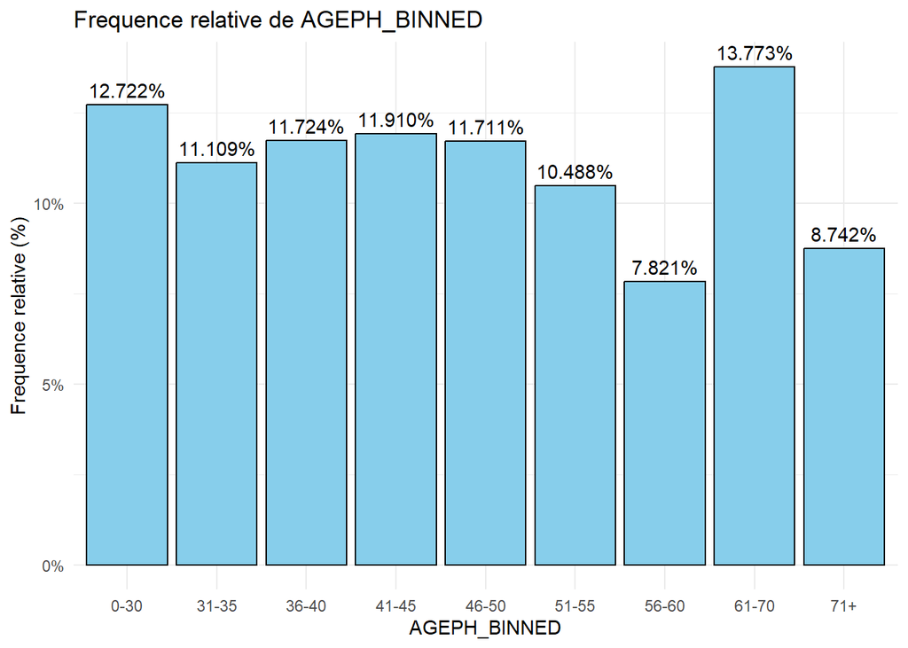

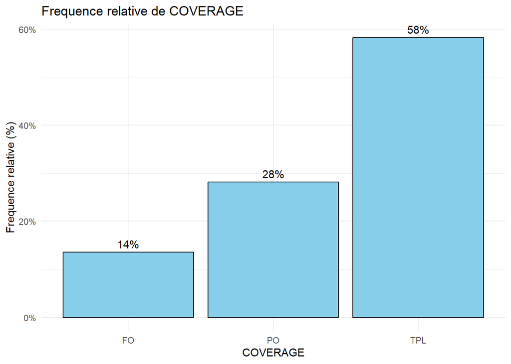

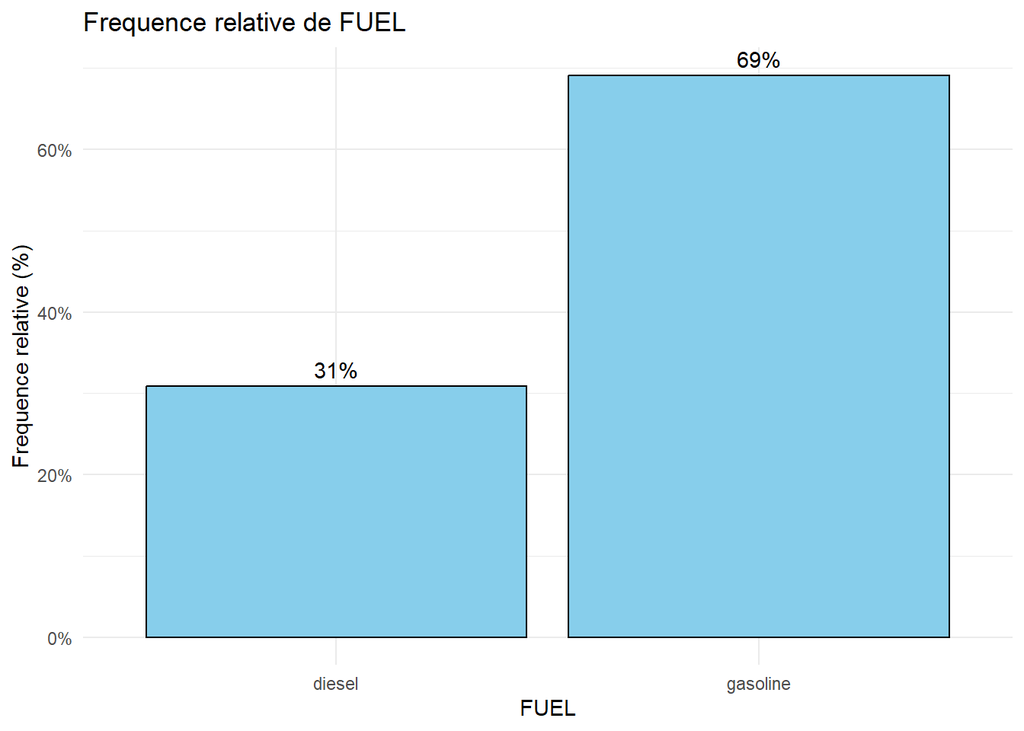

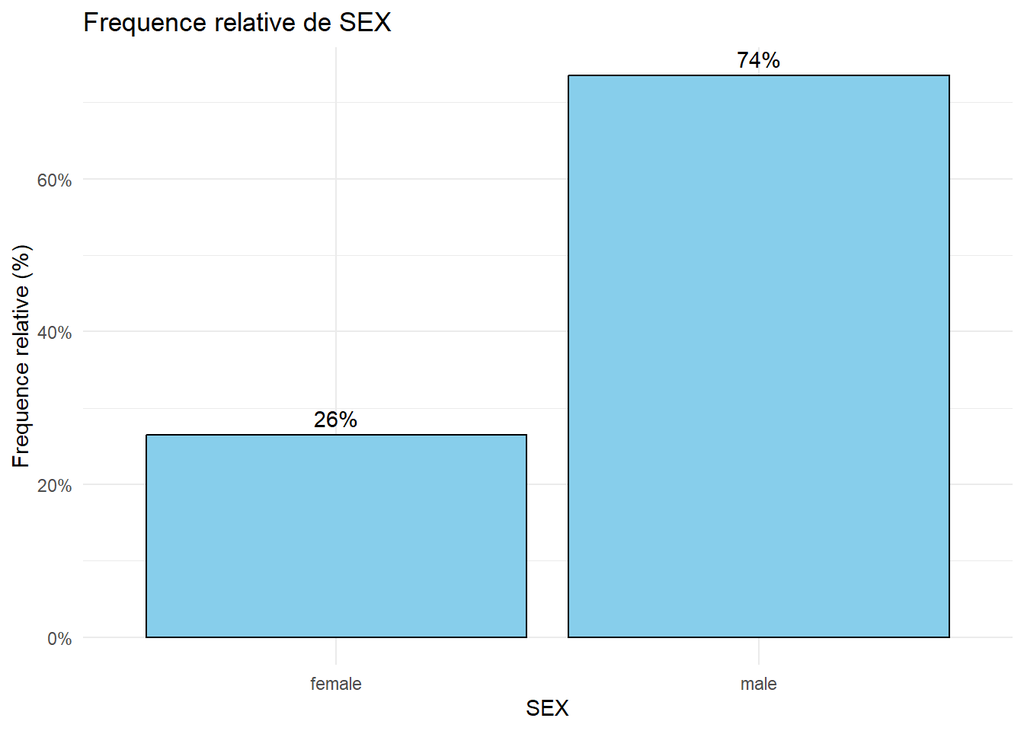

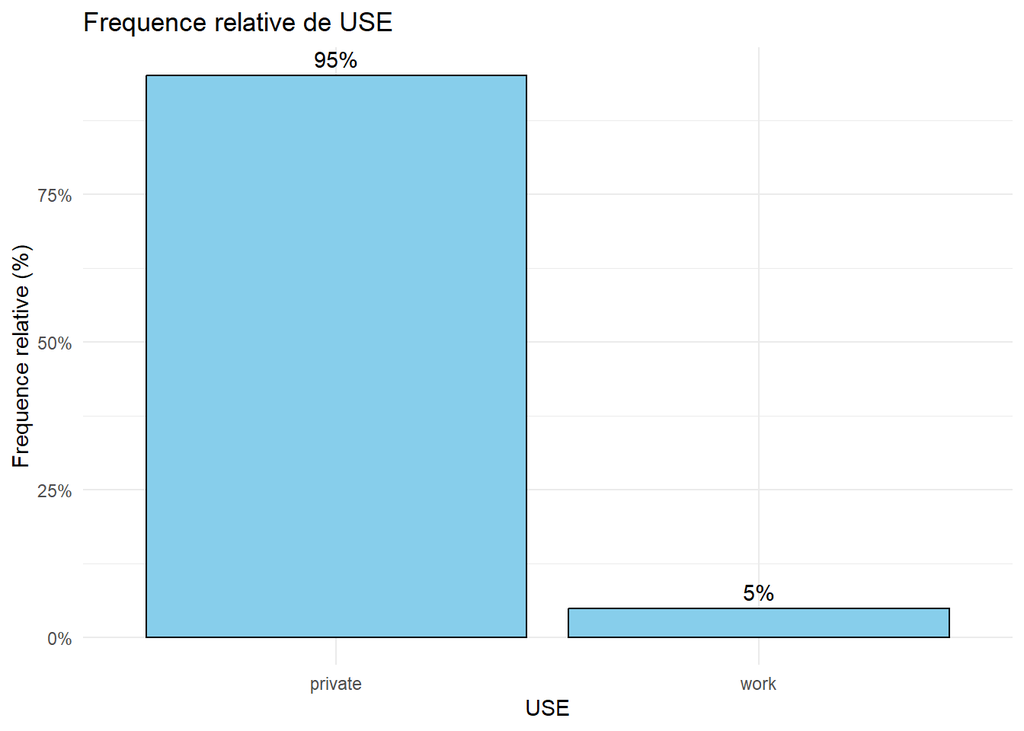

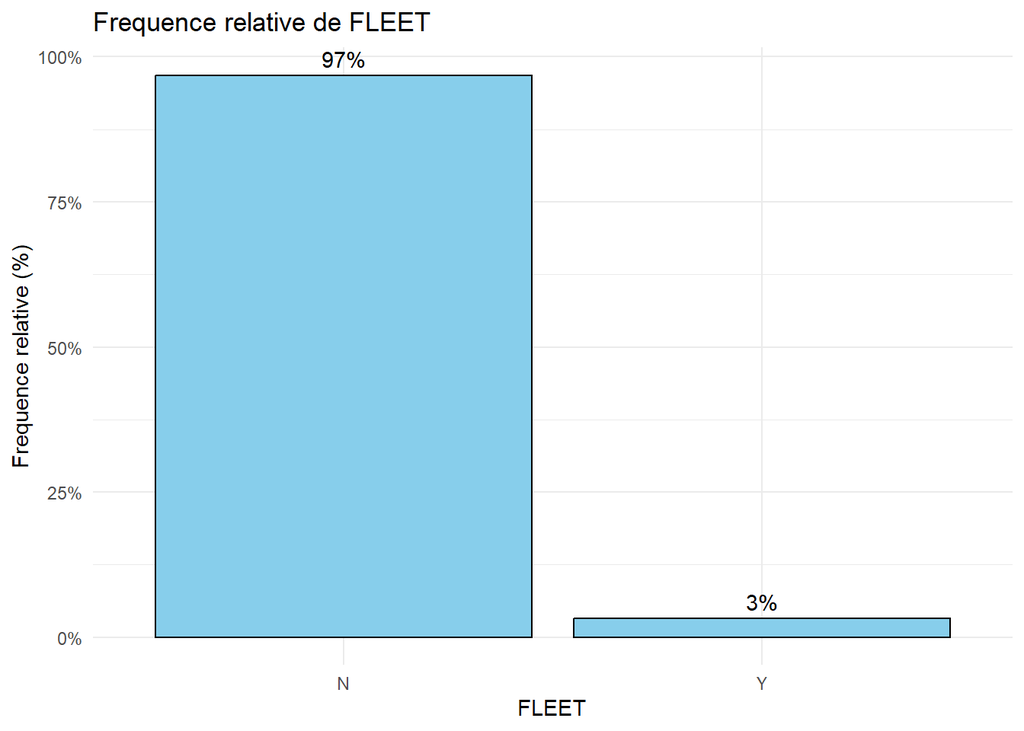

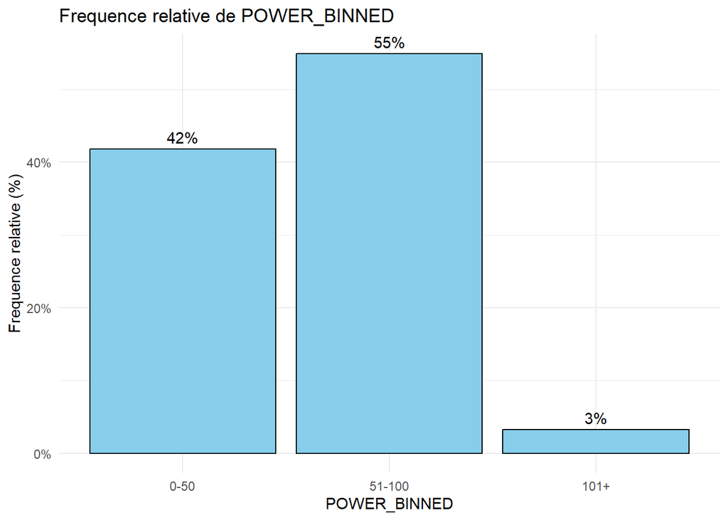

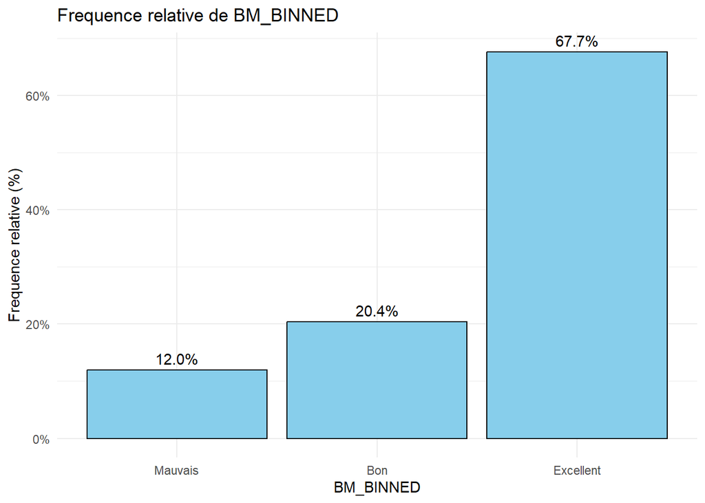

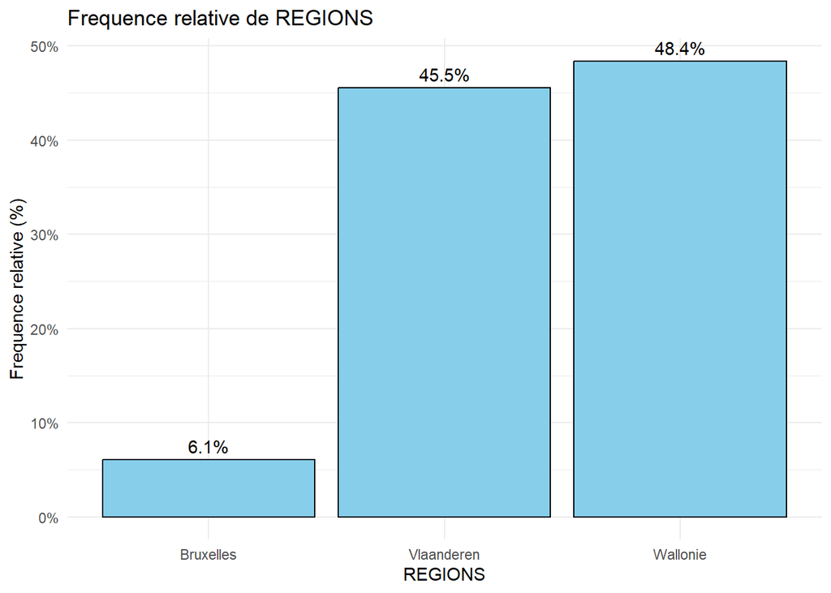

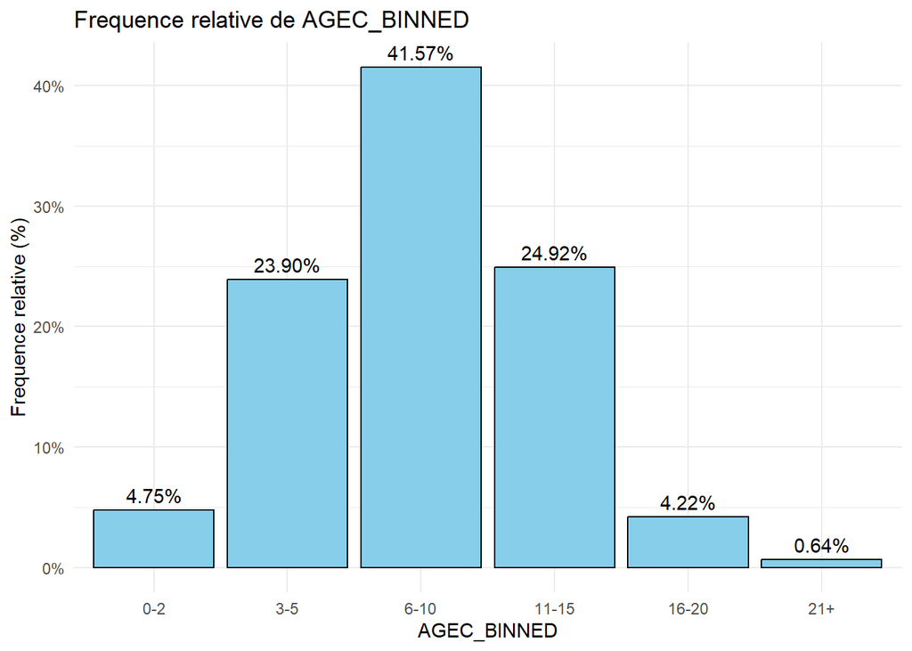

```r
plot_relative_frequency <- function(variable_name) {
  ggplot(data, aes_string(x = variable_name)) +
    geom_bar(aes(y = (..count..) / sum(..count..)), fill = "skyblue", color = "black") +
    geom_text(
      stat = "count",
      aes(label = scales::percent(..count.. / sum(..count..)), y = (..count..) / sum(..count..)),
      vjust = -0.5
    ) +
    scale_y_continuous(labels = scales::percent) +
    labs(
      title = paste("Frequence relative de", variable_name),
      x = variable_name,
      y = "Frequence relative (%)"
    ) +
    theme_minimal()
}

variables <- c("AGEPH_BINNED", "COVERAGE", "FUEL", "SEX", "USE", "FLEET", "POWER_BINNED", "BM_BINNED",'REGIONS',"AGEC_BINNED")


plots <- lapply(variables, plot_relative_frequency)
par(mfrow = c(3, 3))

for (i in seq_along(variables)) {
  plot(plots[[i]])
}
```

## 2.1 **Résultats**

1. **AGEPH_BINNED (Âge des assurés)**

La répartition est relativement homogène avec des fréquences relatives comprises entre *7,8 %* et *13,8 %*. La tranche d’âge 61-70 ans est la plus représentée avec *13,8 %*, ce qui pourrait indiquer une population plus âgée dans le portefeuille enfin la tranche d’âge 56-60 ans est sous-représentée *(7,8 %)*.

2. **COVERAGE (Type de couverture)**

La couverture **TPL** est la plus populaire avec *58 %* des contrats, reflétant peut-être une préférence pour la couverture minimale obligatoire. Les couvertures **FO** et **PO** représentent respectivement *14 %* et *28 %*, indiquant que seuls certains segments du portefeuille optent pour des protections supplémentaires.

3. **FUEL (Type de carburant)**  
   Une large majorité *(69 %)* des véhicules fonctionnent à l’essence, tandis que 31 % utilisent le diesel.
4. **SEX (Sexe de l’assuré)**

La majorité des assurés sont des hommes *(74 %)*, contre *26 %* de femmes.

5. **USE (Utilisation du véhicule)**

La majorité des véhicules sont utilisés à titre privé *(95 %)*, avec seulement *5 %* pour le travail.

6. **FLEET (Véhicules en flotte)**

Seulement *3 %* des véhicules appartiennent à des flottes, corroborant que le portefeuille se concentre principalement sur les particuliers.

7. **POWER_BINNED (Puissance du véhicule)**  
   Les véhicules avec une puissance modérée (51-100 kW) dominent avec *55 %* des observations. Les véhicules à basse puissance (0-50 kW) représentent *42 %*, tandis que ceux à haute puissance (>101 kW) sont rares *(3 %)*.
8. **BM_BINNED (Bonus-Malus)**

Une majorité *(67,7 %)* des assurés ont un excellent historique de sinistres, suivie de *20,4 %* avec un bon historique. Une minorité *(12 %)* est classée dans la catégorie mauvais.

## 2.2 **Analyse de la sinistralité en fonction des differents variables explicative**

```r
analyze_variable <- function(data, var_name, exposure_col = "EXP", claim_col = "NCLAIMS") {
  # Résumé des données
  summary_df <- data %>%
    group_by(.data[[var_name]]) %>%
    summarise(
      Number.Observations = n(),
      Number.Claims = sum(.data[[claim_col]], na.rm = TRUE),
      Obs.Claim.Frequency = sum(.data[[claim_col]], na.rm = TRUE) / sum(.data[[exposure_col]], na.rm = TRUE)
    )

  portfolio_cf <- sum(data[[claim_col]], na.rm = TRUE) / sum(data[[exposure_col]], na.rm = TRUE)

  plot_claim_frequency <- ggplot(summary_df, aes_string(
    x = var_name, y = "Obs.Claim.Frequency", fill = "Obs.Claim.Frequency"
  )) +
    geom_bar(stat = "identity", width = 0.6, color = "black") +
    geom_hline(yintercept = portfolio_cf, color = "red", linetype = "dashed", linewidth = 1.2) +
    geom_text(aes(label = scales::percent(Obs.Claim.Frequency, accuracy = 0.01)),
              vjust = -0.5, size = 4.5, color = "green") +
    annotate(
      "text", x = 1, y = portfolio_cf * 1.1,
      label = paste("Portfolio Avg Claim Freq:", scales::percent(portfolio_cf, accuracy = 0.01)),
      color = "red", size = 5, fontface = "italic", hjust = 0
    ) +
    scale_y_continuous(
      name = "Observed Claim Frequency",
      labels = scales::percent_format(accuracy = 0.01),
      expand = expansion(mult = c(0, 0.1))
    ) +
    scale_fill_viridis_c(guide = "none") +
    labs(
      title = paste("Observed Claim Frequency by", var_name),
      x = var_name,
      y = "Observed Claim Frequency"
    ) +
    theme_minimal(base_size = 14) +
    theme(
      axis.text.x = element_text(angle = 45, hjust = 1),
      plot.title = element_text(size = 18, face = "bold", hjust = 0.5)
    )

  return(plot_claim_frequency)
}
```

**REGIONS**

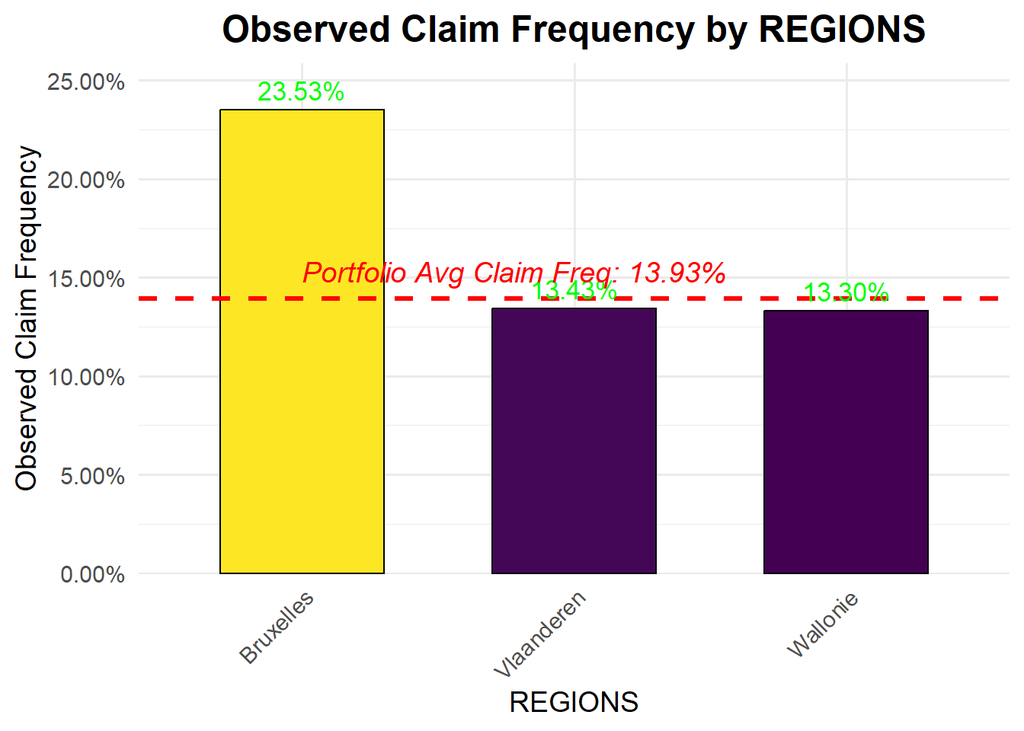

```r
analyze_variable(data, "REGIONS")
```

La Région de Bruxelles affiche une fréquence des sinistres nettement plus élevée à **23,53 %**, bien au-dessus de la moyenne du portefeuille. La Flandre et la Wallonie ont des fréquences similaires, respectivement **13,43 %** et **13,30 %**, légèrement en dessous de la moyenne.

**POWER_BINNED**

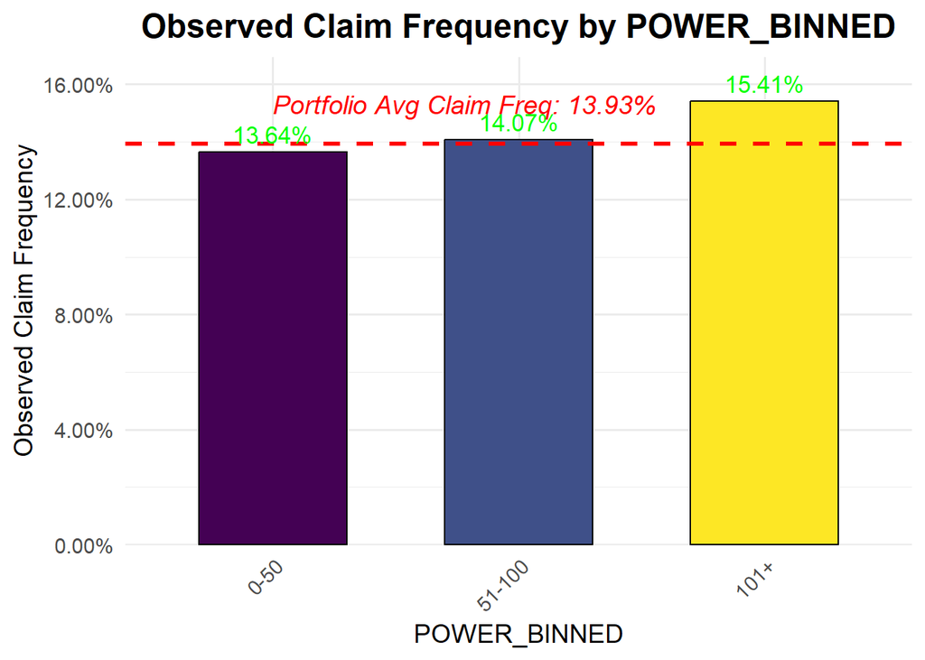

```r
analyze_variable(data, "POWER_BINNED")
```

• Catégorie 0-50 : La fréquence des sinistres est de **13,64%**, légèrement inférieure à la moyenne du portefeuille (13,93%).

• Catégorie 51-100 : La fréquence des sinistres est légèrement supérieure à la moyenne, à **14,07%**, suggérant un risque légèrement plus élevé pour cette plage de puissance.

• Catégorie 101+ : La fréquence atteint **15,41%**, bien au-dessus de la moyenne. Cela pourrait indiquer un risque accru pour les véhicules de haute puissance, peut-être en raison d’une conduite plus agressive ou d’une utilisation plus risquée.

**COVERAGE**

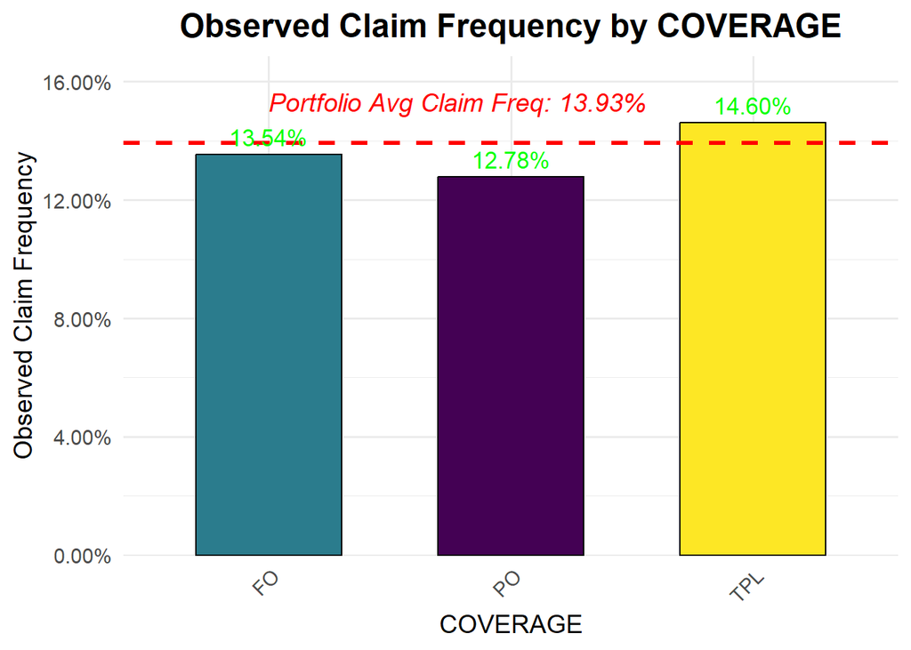

```r
analyze_variable(data, "COVERAGE")
```

• FO : Une fréquence de 13,54%, juste en dessous de la moyenne, indique un risque relativement stable pour cette couverture.

• PO : La fréquence chute légèrement à 12,78%, ce qui peut refléter une meilleure gestion des risques pour les assurés ayant choisi une protection supplémentaire.

• TPL : Une augmentation à 14,60% montre un risque légèrement plus élevé pour cette couverture obligatoire.

**AGEPH_BINNED (age de l’assuré)**

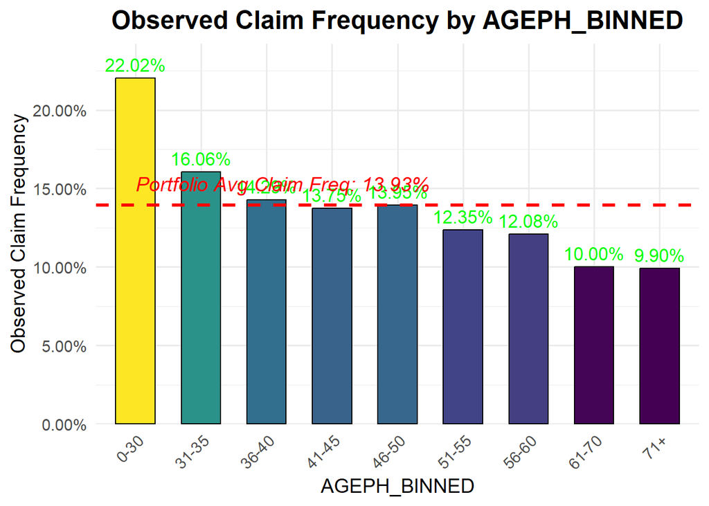

```r
analyze_variable(data, "AGEPH_BINNED")
```

• Une diminution progressive est observée pour les âges 31-35 à 46-50, où les fréquences se stabilisent autour de 13 et 14%, indiquant un risque modéré.

• Les conducteurs âgés (61-70 ans et 71+) ont une fréquence de sinistres inférieure à la moyenne (10,00% et 9,90%, respectivement), ce qui pourrait refléter une conduite plus prudente ou une moindre utilisation du véhicule.

**BM_BINNED (Bonus Malus)**

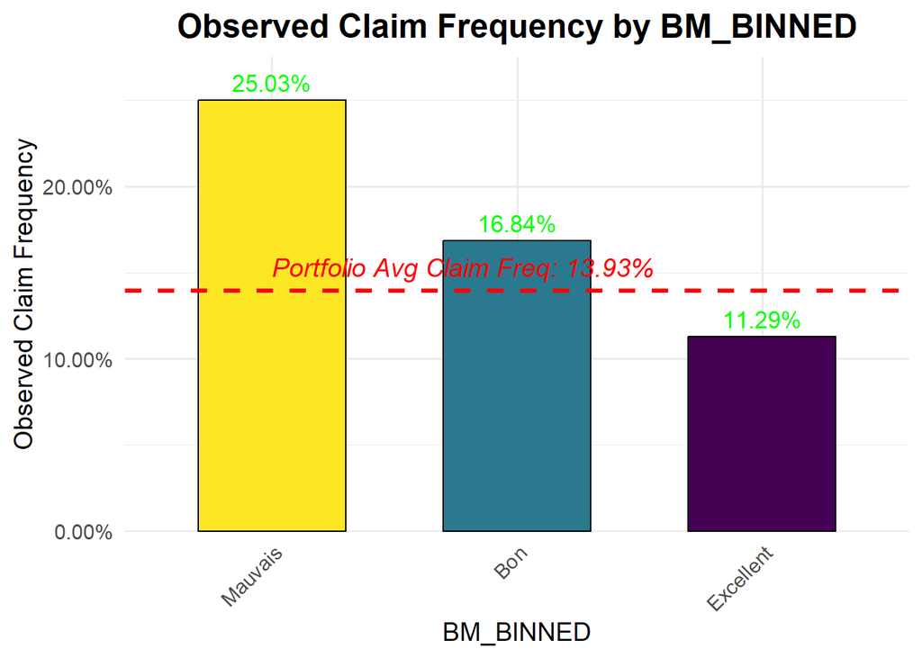

```r
analyze_variable(data, "BM_BINNED")
```

**SEXE**

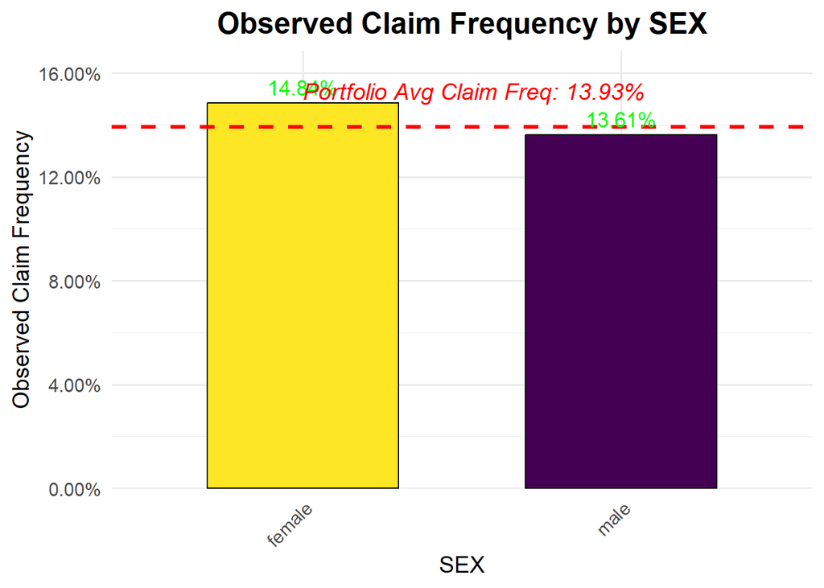

```r
analyze_variable(data, "SEX")
```

**USE**

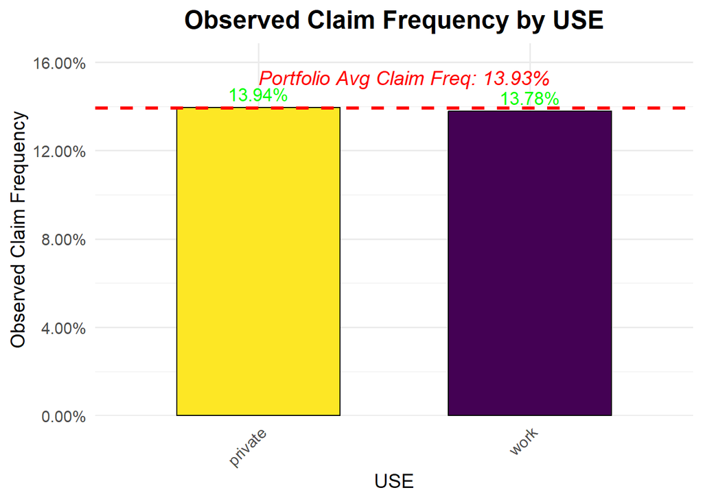

```r
analyze_variable(data, "USE")
```

Les véhicules à usage privé ont une fréquence des sinistres de 13,94%, alignée avec la moyenne du portefeuille (13,93%). Tandis que, les véhicules à usage professionnel ont une fréquence légèrement inférieure à 13,78%.

**FLEET**

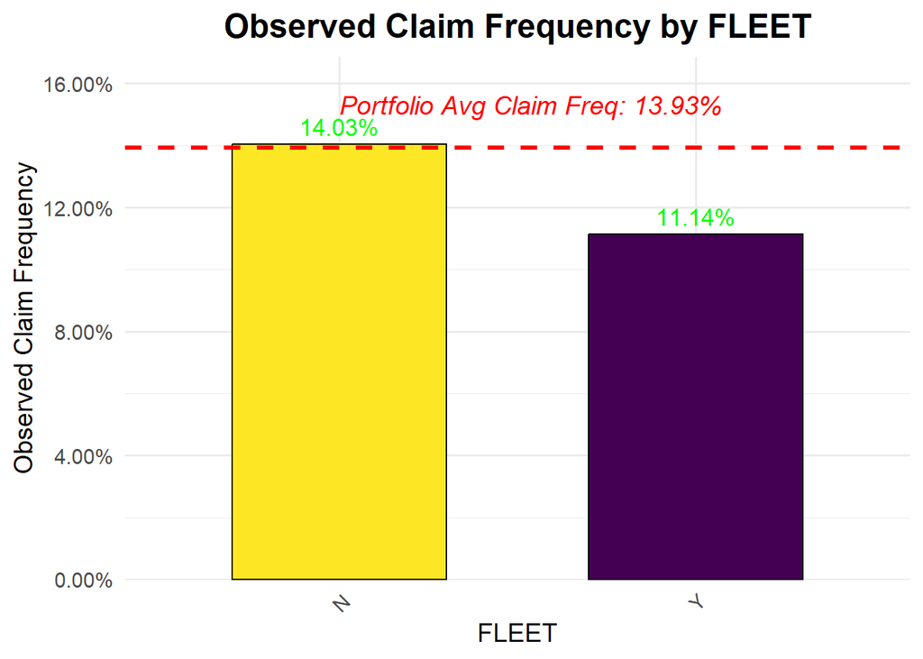

```r
analyze_variable(data, "FLEET")
```

Les véhicules non-flotte présentent une fréquence des sinistres de **14,03%**, légèrement supérieure à la moyenne du portefeuille. Alors que, les véhicules appartenant à une flotte ont une fréquence nettement plus faible, à **11,14%**, indiquant une meilleure gestion des risques ou une utilisation contrôlée des véhicules de flotte.

**AGEC_BINNED**

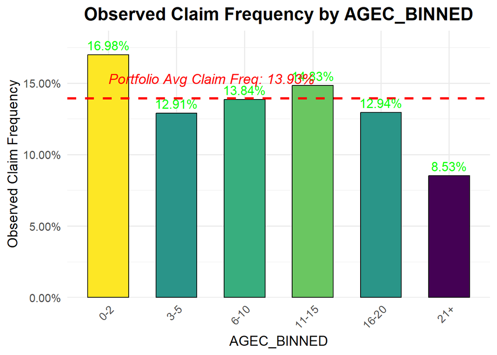

```r
analyze_variable(data, "AGEC_BINNED")
```

## 2.3 **Analyse de la variable target NCLAIMS**

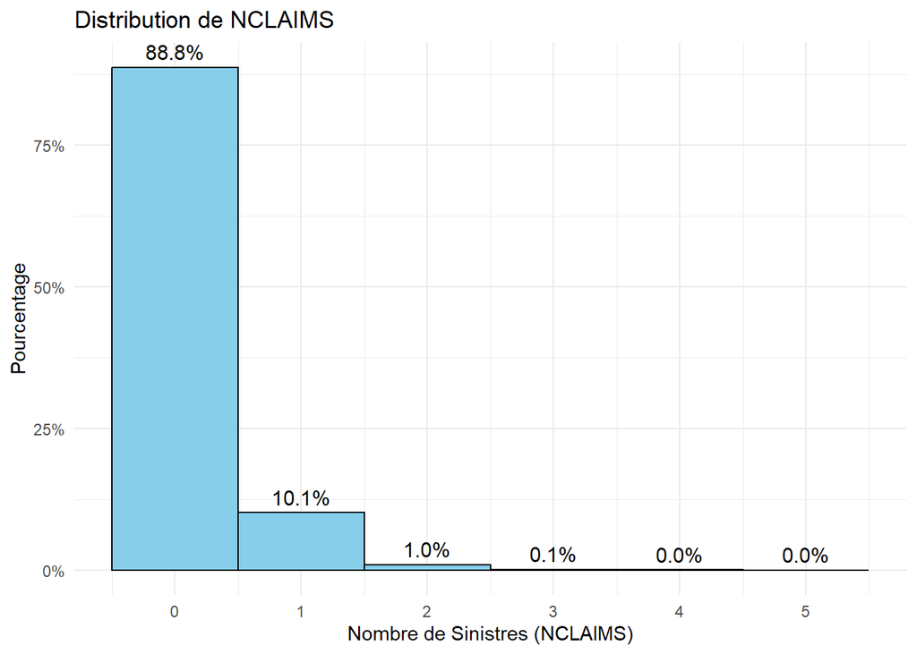

```r
ggplot(data, aes(x = NCLAIMS)) +
  geom_histogram(
    aes(y = ..count../sum(..count..)),
    binwidth = 1,
    fill = "skyblue",
    color = "black"
  ) +
  geom_text(
    stat = "bin",
    aes(y = ..count../sum(..count..), label = scales::percent(..count../sum(..count..), accuracy = 0.1)),
    binwidth = 1,
    vjust = -0.5,
    size = 4
  ) +
  scale_x_continuous(breaks = seq(0, max(data$NCLAIMS), by = 1)) +
  scale_y_continuous(labels = scales::percent) +  # Afficher l'axe des y en pourcentage
  labs(
    title = "Distribution de NCLAIMS",
    x = "Nombre de Sinistres (NCLAIMS)",
    y = "Pourcentage"
  ) +
  theme_minimal()
```

**88%** des assurés n’ont déclaré aucun sinistre.

## 2.4 **Choix de la loi de la fréquence des sinistres: quelques test**

Cette section vise à vérifier si la fréquence des sinistres suit une **loi de Poisson**, bien que nous utiliserons cette loi dans notre modélisation.

```r
x=rpois(length(data$NCLAIMS),mean(data$NCLAIMS))
ks.test(data$NCLAIMS,x)
```

```
##
##  Asymptotic two-sample Kolmogorov-Smirnov test
##
## data:  data$NCLAIMS and x
## D = 0.004656, p-value = 0.05811
## alternative hypothesis: two-sided
```

#### 2.4.0.1 **Hypothèses du test** :

- **Hypothèse nulle (H0)** : Les données observées (data$NCLAIMS) et les données générées aléatoirement à partir d’une loi de Poisson avec la même moyenne suivent la même distribution.
- **Hypothèse alternative (H1)** : Les deux distributions diffèrent.

# 3 **Modelisation GLM**

## 3.1 **Modele de Frequence**

```r
data$COVERAGE = data$COVERAGE %>% fct_infreq()
levels(data$COVERAGE)
```

```
## [1] "TPL" "PO"  "FO"
```

```r
data$FUEL = data$FUEL %>% fct_infreq()
levels(data$FUEL)
```

```
## [1] "gasoline" "diesel"
```

```r
data$SEX = data$SEX %>% fct_infreq()
levels(data$SEX)
```

```
## [1] "male"   "female"
```

```r
data$REGIONS = data$REGIONS %>% fct_infreq()
levels(data$REGIONS)
```

```
## [1] "Wallonie"   "Vlaanderen" "Bruxelles"
```

**Train-test-split**

```r
set.seed(21)
in_training = createDataPartition(data$NCLAIMS, times = 1, p = 0.8, list = FALSE)
training_set = data[in_training, ]
testing_set = data[-in_training, ]
```

### 3.1.1 **Estimation**

**Modele null vs modele complet**

```r
# Modèle nul

null_model <- glm(NCLAIMS ~ offset(log(EXP)), family = poisson(link = log), data = training_set)

# Modèle complet

full_model <- glm(NCLAIMS ~ offset(log(EXP)) + COVERAGE + FUEL + USE + FLEET + SEX +
                    AGEPH_BINNED + POWER_BINNED + BM_BINNED + REGIONS + AGEC_BINNED,
                  family = poisson(link = log), data = training_set)
```

```r
summary(null_model)
```

```
##
## Call:
## glm(formula = NCLAIMS ~ offset(log(EXP)), family = poisson(link = log),
##     data = training_set)
##
## Coefficients:
##              Estimate Std. Error z value Pr(>|z|)
## (Intercept) -1.967969   0.007851  -250.7   <2e-16 ***
## ---
## Signif. codes:  0 '***' 0.001 '**' 0.01 '*' 0.05 '.' 0.1 ' ' 1
##
## (Dispersion parameter for poisson family taken to be 1)
##
##     Null deviance: 71970  on 130584  degrees of freedom
## Residual deviance: 71970  on 130584  degrees of freedom
## AIC: 102284
##
## Number of Fisher Scoring iterations: 6
```

### 3.1.2 **Interpretation du modele null**

Le coefficient estimé pour l’interception est de **-1.967969**. Cela représente le logarithme naturel de la fréquence annuelle moyenne des sinistres, une fois l’exposition (EXP) prise en compte. En d’autres termes, un assuré génère en moyenne environ 0,14 sinistre par an, ce qui correspond à un sinistre tous les 7 ans environ.

```r
BIC(null_model, full_model)
```

```
##            df      BIC
## null_model  1 102294.0
## full_model 26 100226.8
```

Selon le critère BIC, le modèle complet (full model) offre un meilleur ajustement que le modèle nul (null model).

```r
# Test ANOVA pour comparer les deux modèles
anova(null_model, full_model, test = "Chisq")
```

```
## Analysis of Deviance Table
##
## Model 1: NCLAIMS ~ offset(log(EXP))
## Model 2: NCLAIMS ~ offset(log(EXP)) + COVERAGE + FUEL + USE + FLEET +
##     SEX + AGEPH_BINNED + POWER_BINNED + BM_BINNED + REGIONS +
##     AGEC_BINNED
##   Resid. Df Resid. Dev Df Deviance  Pr(>Chi)
## 1    130584      71970
## 2    130559      69609 25   2361.6 < 2.2e-16 ***
## ---
## Signif. codes:  0 '***' 0.001 '**' 0.01 '*' 0.05 '.' 0.1 ' ' 1
```

```r
summary(full_model)
```

```
##
## Call:
## glm(formula = NCLAIMS ~ offset(log(EXP)) + COVERAGE + FUEL +
##     USE + FLEET + SEX + AGEPH_BINNED + POWER_BINNED + BM_BINNED +
##     REGIONS + AGEC_BINNED, family = poisson(link = log), data = training_set)
##
## Coefficients:
##                    Estimate Std. Error z value Pr(>|z|)
## (Intercept)        -1.14495    0.04436 -25.811  < 2e-16 ***
## COVERAGEPO         -0.08717    0.01967  -4.431 9.38e-06 ***
## COVERAGEFO         -0.07645    0.02752  -2.778  0.00546 **
## FUELdiesel          0.19027    0.01711  11.120  < 2e-16 ***
## USEwork            -0.03892    0.03731  -1.043  0.29678
## FLEETY             -0.15286    0.04891  -3.125  0.00178 **
## SEXfemale           0.03430    0.01810   1.896  0.05802 .
## AGEPH_BINNED31-35  -0.19141    0.02930  -6.532 6.47e-11 ***
## AGEPH_BINNED36-40  -0.23746    0.03035  -7.825 5.08e-15 ***
## AGEPH_BINNED41-45  -0.23180    0.03061  -7.573 3.63e-14 ***
## AGEPH_BINNED46-50  -0.19687    0.03054  -6.447 1.14e-10 ***
## AGEPH_BINNED51-55  -0.33086    0.03299 -10.030  < 2e-16 ***
## AGEPH_BINNED56-60  -0.31507    0.03630  -8.679  < 2e-16 ***
## AGEPH_BINNED61-70  -0.51823    0.03301 -15.699  < 2e-16 ***
## AGEPH_BINNED71+    -0.46959    0.03833 -12.250  < 2e-16 ***
## POWER_BINNED51-100  0.07871    0.01697   4.638 3.52e-06 ***
## POWER_BINNED101+    0.22515    0.04505   4.998 5.79e-07 ***
## BM_BINNEDBon       -0.32189    0.02418 -13.313  < 2e-16 ***
## BM_BINNEDExcellent -0.60468    0.02330 -25.953  < 2e-16 ***
## REGIONSVlaanderen  -0.03063    0.01696  -1.806  0.07091 .
## REGIONSBruxelles    0.44461    0.02869  15.495  < 2e-16 ***
## AGEC_BINNED3-5     -0.27950    0.03720  -7.513 5.80e-14 ***
## AGEC_BINNED6-10    -0.21451    0.03702  -5.794 6.88e-09 ***
## AGEC_BINNED11-15   -0.19121    0.03917  -4.881 1.05e-06 ***
## AGEC_BINNED16-20   -0.31290    0.05474  -5.716 1.09e-08 ***
## AGEC_BINNED21+     -0.61820    0.13326  -4.639 3.50e-06 ***
## ---
## Signif. codes:  0 '***' 0.001 '**' 0.01 '*' 0.05 '.' 0.1 ' ' 1
##
## (Dispersion parameter for poisson family taken to be 1)
##
##     Null deviance: 71970  on 130584  degrees of freedom
## Residual deviance: 69609  on 130559  degrees of freedom
## AIC: 99973
##
## Number of Fisher Scoring iterations: 6
```

Étant donné que la variable **sexe** n’est pas statistiquement significative, nous allons l’exclure du modèle et procéder à une nouvelle estimation.

**Modele sans la variable SEX**

```r
model_sans_sex <- glm(NCLAIMS ~ offset(log(EXP)) + COVERAGE + FUEL + USE + FLEET +
                        AGEPH_BINNED + POWER_BINNED + BM_BINNED + REGIONS + AGEC_BINNED,
                      family = poisson(link = log), data = training_set)
summary(model_sans_sex)
```

```
##
## Call:
## glm(formula = NCLAIMS ~ offset(log(EXP)) + COVERAGE + FUEL +
##     USE + FLEET + AGEPH_BINNED + POWER_BINNED + BM_BINNED + REGIONS +
##     AGEC_BINNED, family = poisson(link = log), data = training_set)
##
## Coefficients:
##                    Estimate Std. Error z value Pr(>|z|)
## (Intercept)        -1.12890    0.04353 -25.934  < 2e-16 ***
## COVERAGEPO         -0.08674    0.01967  -4.410 1.04e-05 ***
## COVERAGEFO         -0.07515    0.02751  -2.732  0.00629 **
## FUELdiesel          0.18589    0.01695  10.965  < 2e-16 ***
## USEwork            -0.03960    0.03731  -1.062  0.28845
## FLEETY             -0.15052    0.04890  -3.078  0.00208 **
## AGEPH_BINNED31-35  -0.19106    0.02930  -6.520 7.01e-11 ***
## AGEPH_BINNED36-40  -0.23744    0.03035  -7.824 5.13e-15 ***
## AGEPH_BINNED41-45  -0.23185    0.03061  -7.574 3.61e-14 ***
## AGEPH_BINNED46-50  -0.19783    0.03054  -6.479 9.26e-11 ***
## AGEPH_BINNED51-55  -0.33293    0.03297 -10.097  < 2e-16 ***
## AGEPH_BINNED56-60  -0.31799    0.03627  -8.767  < 2e-16 ***
## AGEPH_BINNED61-70  -0.52261    0.03293 -15.870  < 2e-16 ***
## AGEPH_BINNED71+    -0.47557    0.03821 -12.448  < 2e-16 ***
## POWER_BINNED51-100  0.07341    0.01674   4.386 1.16e-05 ***
## POWER_BINNED101+    0.21690    0.04484   4.837 1.31e-06 ***
## BM_BINNEDBon       -0.32257    0.02418 -13.342  < 2e-16 ***
## BM_BINNEDExcellent -0.60703    0.02327 -26.084  < 2e-16 ***
## REGIONSVlaanderen  -0.02980    0.01696  -1.757  0.07884 .
## REGIONSBruxelles    0.44534    0.02869  15.521  < 2e-16 ***
## AGEC_BINNED3-5     -0.27907    0.03720  -7.501 6.32e-14 ***
## AGEC_BINNED6-10    -0.21427    0.03702  -5.787 7.14e-09 ***
## AGEC_BINNED11-15   -0.19089    0.03917  -4.873 1.10e-06 ***
## AGEC_BINNED16-20   -0.31337    0.05474  -5.725 1.04e-08 ***
## AGEC_BINNED21+     -0.62009    0.13326  -4.653 3.27e-06 ***
## ---
## Signif. codes:  0 '***' 0.001 '**' 0.01 '*' 0.05 '.' 0.1 ' ' 1
##
## (Dispersion parameter for poisson family taken to be 1)
##
##     Null deviance: 71970  on 130584  degrees of freedom
## Residual deviance: 69612  on 130560  degrees of freedom
## AIC: 99974
##
## Number of Fisher Scoring iterations: 6
```

**BIC**

```r
BIC(model_sans_sex, full_model)
```

```
##                df      BIC
## model_sans_sex 25 100218.6
## full_model     26 100226.8
```

Selon le critère **BIC**, le modèle complet sans la variable sexe offre un meilleur ajustement que le modèle full (full model).

Les resultats du modele avec omission du sexe montre que la variable **USE** n’est pas statistiquement significative, nous allons l’exclure du modèle et procéder à une nouvelle estimation.

### 3.1.3 **Modele sans les variables USE et SEXE**

```r
modele_sans_sex_use <- glm(NCLAIMS ~ offset(log(EXP)) + COVERAGE + FUEL + FLEET +
                             AGEPH_BINNED + POWER_BINNED + BM_BINNED + REGIONS + AGEC_BINNED,
                           family = poisson(link = log), data = training_set)
summary(modele_sans_sex_use)
```

```
##
## Call:
## glm(formula = NCLAIMS ~ offset(log(EXP)) + COVERAGE + FUEL +
##     FLEET + AGEPH_BINNED + POWER_BINNED + BM_BINNED + REGIONS +
##     AGEC_BINNED, family = poisson(link = log), data = training_set)
##
## Coefficients:
##                    Estimate Std. Error z value Pr(>|z|)
## (Intercept)        -1.12846    0.04352 -25.927  < 2e-16 ***
## COVERAGEPO         -0.08706    0.01967  -4.426 9.58e-06 ***
## COVERAGEFO         -0.07742    0.02743  -2.823  0.00476 **
## FUELdiesel          0.18468    0.01692  10.917  < 2e-16 ***
## FLEETY             -0.15433    0.04877  -3.164  0.00155 **
## AGEPH_BINNED31-35  -0.19182    0.02929  -6.548 5.83e-11 ***
## AGEPH_BINNED36-40  -0.23894    0.03032  -7.882 3.23e-15 ***
## AGEPH_BINNED41-45  -0.23330    0.03058  -7.629 2.36e-14 ***
## AGEPH_BINNED46-50  -0.19943    0.03050  -6.539 6.20e-11 ***
## AGEPH_BINNED51-55  -0.33469    0.03293 -10.163  < 2e-16 ***
## AGEPH_BINNED56-60  -0.31996    0.03622  -8.833  < 2e-16 ***
## AGEPH_BINNED61-70  -0.52399    0.03291 -15.924  < 2e-16 ***
## AGEPH_BINNED71+    -0.47706    0.03818 -12.495  < 2e-16 ***
## POWER_BINNED51-100  0.07253    0.01672   4.338 1.44e-05 ***
## POWER_BINNED101+    0.21238    0.04464   4.757 1.96e-06 ***
## BM_BINNEDBon       -0.32164    0.02416 -13.312  < 2e-16 ***
## BM_BINNEDExcellent -0.60562    0.02323 -26.067  < 2e-16 ***
## REGIONSVlaanderen  -0.03012    0.01695  -1.776  0.07566 .
## REGIONSBruxelles    0.44494    0.02869  15.509  < 2e-16 ***
## AGEC_BINNED3-5     -0.27982    0.03720  -7.523 5.36e-14 ***
## AGEC_BINNED6-10    -0.21486    0.03702  -5.805 6.45e-09 ***
## AGEC_BINNED11-15   -0.19119    0.03917  -4.881 1.05e-06 ***
## AGEC_BINNED16-20   -0.31355    0.05474  -5.728 1.01e-08 ***
## AGEC_BINNED21+     -0.62030    0.13326  -4.655 3.24e-06 ***
## ---
## Signif. codes:  0 '***' 0.001 '**' 0.01 '*' 0.05 '.' 0.1 ' ' 1
##
## (Dispersion parameter for poisson family taken to be 1)
##
##     Null deviance: 71970  on 130584  degrees of freedom
## Residual deviance: 69613  on 130561  degrees of freedom
## AIC: 99973
##
## Number of Fisher Scoring iterations: 6
```

```r
BIC(model_sans_sex, modele_sans_sex_use)
```

```
##                     df      BIC
## model_sans_sex      25 100218.6
## modele_sans_sex_use 24 100208.0
```

Selon le critère BIC, le modèle **modèle_sans_sex_use** est supérieur au modèle **modèle_sans_sex**.

### 3.1.5 **Selection des variables grace à la méthode du Backward induction**

```r
step_result <- step(
  full_model,
  direction = "backward",
  k = log(nrow(training_set)),
  trace = 1
)
```

```
## Start:  AIC=100226.8
## NCLAIMS ~ offset(log(EXP)) + COVERAGE + FUEL + USE + FLEET +
##     SEX + AGEPH_BINNED + POWER_BINNED + BM_BINNED + REGIONS +
##     AGEC_BINNED
##
##                Df Deviance    AIC
## - USE           1    69610 100216
## - SEX           1    69612 100219
## - COVERAGE      2    69630 100225
## - FLEET         1    69619 100225
## <none>               69609 100227
## - POWER_BINNED  2    69645 100240
## - AGEC_BINNED   5    69683 100242
## - FUEL          1    69730 100337
## - AGEPH_BINNED  8    69926 100450
## - REGIONS       2    69857 100452
## - BM_BINNED     2    70264 100859
##
## Step:  AIC=100216.1
## NCLAIMS ~ COVERAGE + FUEL + FLEET + SEX + AGEPH_BINNED + POWER_BINNED +
##     BM_BINNED + REGIONS + AGEC_BINNED + offset(log(EXP))
##
##                Df Deviance    AIC
## - SEX           1    69613 100208
## - COVERAGE      2    69632 100215
## - FLEET         1    69620 100215
## <none>               69610 100216
## - POWER_BINNED  2    69645 100228
## - AGEC_BINNED   5    69684 100232
## - FUEL          1    69730 100325
## - REGIONS       2    69858 100441
## - AGEPH_BINNED  8    69930 100442
## - BM_BINNED     2    70264 100847
##
## Step:  AIC=100208
## NCLAIMS ~ COVERAGE + FUEL + FLEET + AGEPH_BINNED + POWER_BINNED +
##     BM_BINNED + REGIONS + AGEC_BINNED + offset(log(EXP))
##
##                Df Deviance    AIC
## - COVERAGE      2    69635 100206
## - FLEET         1    69624 100207
## <none>               69613 100208
## - POWER_BINNED  2    69646 100217
## - AGEC_BINNED   5    69688 100224
## - FUEL          1    69730 100313
## - REGIONS       2    69862 100433
## - AGEPH_BINNED  8    69944 100444
## - BM_BINNED     2    70275 100846
##
## Step:  AIC=100206.3
## NCLAIMS ~ FUEL + FLEET + AGEPH_BINNED + POWER_BINNED + BM_BINNED +
##     REGIONS + AGEC_BINNED + offset(log(EXP))
##
##                Df Deviance    AIC
## <none>               69635 100206
## - FLEET         1    69648 100207
## - POWER_BINNED  2    69665 100213
## - AGEC_BINNED   5    69714 100226
## - FUEL          1    69750 100309
## - REGIONS       2    69873 100420
## - AGEPH_BINNED  8    69970 100447
## - BM_BINNED     2    70318 100865
```

En utilisant la méthode de sélection **Backward**, les variables retenues sont : **FLEET**, **POWER_BINNED**, **AGEC_BINNED**, **FUEL**, **REGIONS**, **AGEPH_BINNED**, et **BM_BINNED**, qui constituent les principaux facteurs de risque. Nous considérons ce modèle comme optimal et allons le sauvegarder pour les analyses ultérieures.

```r
anova(step_result,modele_sans_sex_use,"Chisq")
```

```
## Analysis of Deviance Table
##
## Model 1: NCLAIMS ~ FUEL + FLEET + AGEPH_BINNED + POWER_BINNED + BM_BINNED +
##     REGIONS + AGEC_BINNED + offset(log(EXP))
## Model 2: NCLAIMS ~ offset(log(EXP)) + COVERAGE + FUEL + FLEET + AGEPH_BINNED +
##     POWER_BINNED + BM_BINNED + REGIONS + AGEC_BINNED
##   Resid. Df Resid. Dev Df Deviance Pr(>Chi)
## 1    130563      69635
## 2    130561      69613  2   21.861 1.79e-05 ***
## ---
## Signif. codes:  0 '***' 0.001 '**' 0.01 '*' 0.05 '.' 0.1 ' ' 1
```

```r
BIC(step_result,modele_sans_sex_use)
```

```
##                     df      BIC
## step_result         22 100206.3
## modele_sans_sex_use 24 100208.0
```

## 3.2 **Interpretation des coefficients**

```r
#summary(step_result)
stargazer(step_result, type = "text", title = "Résumé du modèle retenu", align = TRUE)
```

```
##
## Résumé du modèle retenu
## ==============================================
##                        Dependent variable:
##                    ---------------------------
##                              NCLAIMS
## ----------------------------------------------
## FUELdiesel                  0.183***
##                              (0.017)
##
## FLEETY                      -0.168***
##                              (0.049)
##
## AGEPH_BINNED31-35           -0.195***
##                              (0.029)
##
## AGEPH_BINNED36-40           -0.241***
##                              (0.030)
##
## AGEPH_BINNED41-45           -0.236***
##                              (0.031)
##
## AGEPH_BINNED46-50           -0.203***
##                              (0.030)
##
## AGEPH_BINNED51-55           -0.339***
##                              (0.033)
##
## AGEPH_BINNED56-60           -0.324***
##                              (0.036)
##
## AGEPH_BINNED61-70           -0.527***
##                              (0.033)
##
## AGEPH_BINNED71+             -0.480***
##                              (0.038)
##
## POWER_BINNED51-100          0.069***
##                              (0.017)
##
```

[output cut: 24 more lines]

```
## AGEC_BINNED16-20            -0.266***
##                              (0.053)
##
## AGEC_BINNED21+              -0.571***
##                              (0.133)
##
## Constant                    -1.179***
##                              (0.041)
##
## ----------------------------------------------
## Observations                 130,585
## Log Likelihood             -49,973.560
## Akaike Inf. Crit.          99,991.120
## ==============================================
## Note:              *p<0.1; **p<0.05; ***p<0.01
```

### 3.2.1 **Interprétation détaillée et exhaustive du modèle step_result**

Soit $X$ une variable à deux modalités $a$ et $b$, avec $a$ comme modalité de référence. Ici, nous interprétons :

$$\frac{E(N \mid X=b) - E(N \mid
X=a)}{E(N \mid X=a)} = \exp(\beta) - 1$$
**1. Résultats du modèle (Intercept) :**

- L’**intercept** représente la fréquence annuelle des sinistres dans la classe de référence. Cela correspond à un assuré ayant les caractéristiques suivantes :
  - **Type de carburant :** véhicule essence (gasoline),
  - **Type de flotte :** non-flotte,
  - **Âge du conducteur :** moins de 30 ans,
  - **Bonus-Malus :** supérieur à 10 (mauvais niveau),
  - **Région :** résident en Wallonie,
  - **Âge du véhicule :** inférieur à 3 ans.

Pour ce profil, la fréquence des sinistres est estimée à **0,30 sinistre par année d’exposition**, soit **31 sinistres pour 100 années d’exposition**.

**FUEL** (Type de carburant, référence : *Essence*)

- **Diesel** : Augmentation de la fréquence des sinistres de **20,3 %** par rapport aux véhicules à essence.

**AGEPH_BINNED** (Âge des conducteurs, référence : *“0-30 ans”*)

- **31-35 ans** : Réduction de **17,5 %** par rapport aux conducteurs âgés de 0 à 30 ans.
- **36-40 ans** : Réduction de **21,4 %** par rapport aux conducteurs âgés de 0 à 30 ans.
- **41-45 ans** : Réduction de **20 %** par rapport aux conducteurs âgés de 0 à 30 ans.
- **46-50 ans** : Réduction de **18,34 %** par rapport aux conducteurs âgés de 0 à 30 ans.
- **51-55 ans** : Réduction de **28,34 %** par rapport aux conducteurs âgés de 0 à 30 ans.
- **56-60 ans** : Réduction de **27,67 %** par rapport aux conducteurs âgés de 0 à 30 ans.
- **61-70 ans** : Réduction de **40,7 %** par rapport aux conducteurs âgés de 0 à 30 ans.
- **Plus de 71 ans** : Réduction de **38,14 %** par rapport aux conducteurs âgés de 0 à 30 ans.

**Interprétation :** La fréquence des sinistres diminue avec l’âge du conducteur, probablement en raison d’une conduite plus prudente et expérimentée chez les conducteurs plus âgés.

**POWER_BINNED** (Puissance des véhicules, référence : *“0-50 kW”*)

**Interprétation :** Les véhicules plus puissants sont associés à des comportements de conduite plus risqués, entraînant une augmentation du risque.

**BM_BINNED** (Bonus-Malus, référence : *Mauvais*)

- **Bon** : Réduction de **27,5 %**.
- **Excellent** : Réduction de **45,5 %**.

**Interprétation :** Le niveau de sinistre diminue au fur et à mesure qu’on descend de l’échelle Bonus-Malus.

**REGIONS** (Région, référence : *Wallonie*)

- **Vlaanderen (Flandre)** : Réduction de **3,0 %** (non significatif, p = 0,075).
- **Bruxelles** : Augmentation de **56,0 %**.

**Interprétation :** La densité urbaine et les conditions de circulation à Bruxelles augmentent le risque de sinistres par rapport à la Wallonie.

### 3.2.2 **Validation croisée**

```r
control <- trainControl(
  method = "cv",
  number = 10,
  savePredictions = "final",
  classProbs = FALSE
)

model <- train(
  NCLAIMS ~ offset(log(EXP)) + FLEET + POWER_BINNED + AGEC_BINNED + FUEL + REGIONS + AGEPH_BINNED + BM_BINNED,
  data = training_set,
  method = "glm",
  family = poisson(),
  trControl = control
)

summary(model)
```

```
##
## Call:
## NULL
##
## Coefficients:
##                       Estimate Std. Error z value Pr(>|z|)
## (Intercept)          -1.427625   0.041516 -34.387  < 2e-16 ***
## FLEETY               -0.095242   0.048636  -1.958 0.050201 .
## `POWER_BINNED51-100`  0.067701   0.016699   4.054 5.03e-05 ***
## `POWER_BINNED101+`    0.183910   0.044521   4.131 3.61e-05 ***
## `AGEC_BINNED3-5`     -0.212593   0.036989  -5.747 9.06e-09 ***
## `AGEC_BINNED6-10`    -0.122852   0.035374  -3.473 0.000515 ***
## `AGEC_BINNED11-15`   -0.112551   0.036988  -3.043 0.002343 **
## `AGEC_BINNED16-20`   -0.263912   0.053040  -4.976 6.50e-07 ***
## `AGEC_BINNED21+`     -0.568265   0.132556  -4.287 1.81e-05 ***
## FUELdiesel            0.181387   0.016915  10.724  < 2e-16 ***
## REGIONSVlaanderen    -0.001773   0.016621  -0.107 0.915029
## REGIONSBruxelles      0.369290   0.028670  12.881  < 2e-16 ***
## `AGEPH_BINNED31-35`  -0.210610   0.029266  -7.196 6.18e-13 ***
## `AGEPH_BINNED36-40`  -0.255412   0.030277  -8.436  < 2e-16 ***
## `AGEPH_BINNED41-45`  -0.237274   0.030539  -7.770 7.88e-15 ***
## `AGEPH_BINNED46-50`  -0.191680   0.030447  -6.295 3.06e-10 ***
## `AGEPH_BINNED51-55`  -0.315100   0.032891  -9.580  < 2e-16 ***
## `AGEPH_BINNED56-60`  -0.302846   0.036198  -8.366  < 2e-16 ***
## `AGEPH_BINNED61-70`  -0.486085   0.032856 -14.794  < 2e-16 ***
## `AGEPH_BINNED71+`    -0.417604   0.038149 -10.947  < 2e-16 ***
## BM_BINNEDBon         -0.261053   0.024159 -10.805  < 2e-16 ***
## BM_BINNEDExcellent   -0.544255   0.023179 -23.481  < 2e-16 ***
## ---
## Signif. codes:  0 '***' 0.001 '**' 0.01 '*' 0.05 '.' 0.1 ' ' 1
##
## (Dispersion parameter for poisson family taken to be 1)
##
##     Null deviance: 72046  on 130584  degrees of freedom
## Residual deviance: 70154  on 130563  degrees of freedom
## AIC: 100510
##
## Number of Fisher Scoring iterations: 6
```

### 3.2.3 **Validation du modele**

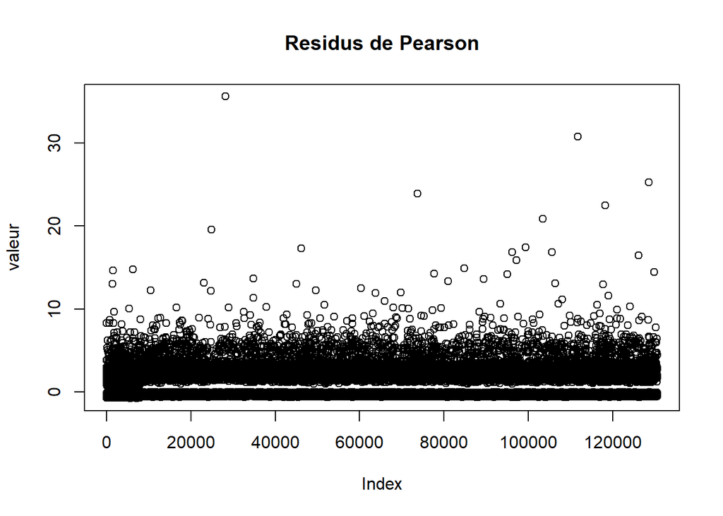

```r
valeur <- residuals.glm(step_result, type = 'pearson')
plot(valeur, main = "Residus de Pearson")
```

**Dans le graphique précédent, la majorité des résidus sont concentrés autour de zéro, ce qui indique que le modèle capture correctement les données dans la plupart des cas. Cela suggère que les écarts entre les valeurs observées et les valeurs prévues ne présentent pas de biais systématique dans une direction particulière. De plus, les résidus semblent homogènes, ce qui est un autre indicateur favorable. Cependant, quelques points s’écartent considérablement de la plage normale (par exemple, au-delà de 10 ou même 30), ce qui pourrait refléter la présence de valeurs aberrantes. Globalement, les résidus semblent cohérents et soutiennent la validité du modèle.**

### 3.2.4 **Prediction sur les données test**

```r
testing_set$predicted_frequency <- predict(step_result, newdata = testing_set, type = "response")
```

**Calcul des métriques de performances**

```r
# Calculer les métriques de performance

observed <- testing_set$NCLAIMS
predicted <- testing_set$predicted_frequency

rmse <- sqrt(mean((observed - predicted)^2))

mae <- mean(abs(observed - predicted))


cat("RMSE:", rmse, "\n")
```

```
## RMSE: 0.367156
```

```r
cat("MAE:", mae, "\n")
```

```
## MAE: 0.2150723
```

## 3.3 **Modele de Severité**

```r
severity_data <- data %>%
  filter(AVG_AMOUNT > 0) %>%
  filter(!is.infinite(AVG_AMOUNT), !is.na(AVG_AMOUNT))
```

**Train_test_Split**

```r
in_training_severity = createDataPartition(severity_data$AVG_AMOUNT, times = 1, p = 0.8, list = FALSE)
training_set_severity = severity_data[in_training_severity, ]
testing_set_severity = severity_data[-in_training_severity, ]
```

```r
null_model_severity <- glm(
  AVG_AMOUNT ~ 1,
  family = Gamma(link = "log"),
  data = training_set_severity
)

summary(null_model_severity)
```

```
##
## Call:
## glm(formula = AVG_AMOUNT ~ 1, family = Gamma(link = "log"), data = training_set_severity)
##
## Coefficients:
##             Estimate Std. Error t value Pr(>|t|)
## (Intercept)  7.41839    0.09229   80.38   <2e-16 ***
## ---
## Signif. codes:  0 '***' 0.001 '**' 0.01 '*' 0.05 '.' 0.1 ' ' 1
##
## (Dispersion parameter for Gamma family taken to be 124.6844)
##
##     Null deviance: 38016  on 14637  degrees of freedom
## Residual deviance: 38016  on 14637  degrees of freedom
## AIC: 240307
##
## Number of Fisher Scoring iterations: 7
```

```r
full_model_severity <- glm(
  AVG_AMOUNT ~ COVERAGE + FUEL + USE + FLEET + SEX + AGEPH_BINNED + POWER_BINNED + BM_BINNED + REGIONS + AGEC_BINNED,
  family = Gamma(link = "log"),
  data = training_set_severity
)
```

```r
summary(full_model_severity)
```

```
##
## Call:
## glm(formula = AVG_AMOUNT ~ COVERAGE + FUEL + USE + FLEET + SEX +
##     AGEPH_BINNED + POWER_BINNED + BM_BINNED + REGIONS + AGEC_BINNED,
##     family = Gamma(link = "log"), data = training_set_severity)
##
## Coefficients:
##                     Estimate Std. Error t value Pr(>|t|)
## (Intercept)         7.804315   0.287250  27.169  < 2e-16 ***
## COVERAGEPO         -0.202645   0.124732  -1.625 0.104259
## COVERAGEFO          0.222898   0.173326   1.286 0.198460
## FUELdiesel         -0.133294   0.108117  -1.233 0.217645
## USEwork            -0.147929   0.235926  -0.627 0.530658
## FLEETY             -0.214421   0.298203  -0.719 0.472125
## SEXfemale           0.159674   0.114147   1.399 0.161880
## AGEPH_BINNED31-35  -0.081781   0.187467  -0.436 0.662667
## AGEPH_BINNED36-40   0.053266   0.192786   0.276 0.782326
## AGEPH_BINNED41-45   0.007178   0.195163   0.037 0.970663
## AGEPH_BINNED46-50   0.077750   0.193703   0.401 0.688141
## AGEPH_BINNED51-55  -0.247432   0.209010  -1.184 0.236499
## AGEPH_BINNED56-60  -0.171344   0.228864  -0.749 0.454068
## AGEPH_BINNED61-70  -0.195208   0.207303  -0.942 0.346385
## AGEPH_BINNED71+     0.028047   0.236752   0.118 0.905701
## POWER_BINNED51-100  0.231627   0.107072   2.163 0.030536 *
## POWER_BINNED101+    0.456023   0.279769   1.630 0.103124
## BM_BINNEDBon       -0.585299   0.156112  -3.749 0.000178 ***
## BM_BINNEDExcellent -0.578276   0.149457  -3.869 0.000110 ***
## REGIONSVlaanderen   0.055330   0.107377   0.515 0.606358
## REGIONSBruxelles   -0.320674   0.183531  -1.747 0.080616 .
## AGEC_BINNED3-5     -0.210730   0.237227  -0.888 0.374390
## AGEC_BINNED6-10     0.008900   0.236683   0.038 0.970003
## AGEC_BINNED11-15    0.005951   0.250788   0.024 0.981069
## AGEC_BINNED16-20   -0.047035   0.349165  -0.135 0.892846
## AGEC_BINNED21+     -0.413850   0.857910  -0.482 0.629534
## ---
## Signif. codes:  0 '***' 0.001 '**' 0.01 '*' 0.05 '.' 0.1 ' ' 1
##
## (Dispersion parameter for Gamma family taken to be 36.0252)
##
##     Null deviance: 38016  on 14637  degrees of freedom
## Residual deviance: 35757  on 14612  degrees of freedom
## AIC: 239176
##
## Number of Fisher Scoring iterations: 19
```

**Comparaison entre le modele Null et le modele full**

```r
anova(null_model_severity, full_model_severity, test = "Chisq")
```

```
## Analysis of Deviance Table
##
## Model 1: AVG_AMOUNT ~ 1
## Model 2: AVG_AMOUNT ~ COVERAGE + FUEL + USE + FLEET + SEX + AGEPH_BINNED +
##     POWER_BINNED + BM_BINNED + REGIONS + AGEC_BINNED
##   Resid. Df Resid. Dev Df Deviance Pr(>Chi)
## 1     14637      38016
## 2     14612      35757 25   2258.4 4.41e-05 ***
## ---
## Signif. codes:  0 '***' 0.001 '**' 0.01 '*' 0.05 '.' 0.1 ' ' 1
```

```r
BIC(null_model_severity, full_model_severity)
```

```
##                     df      BIC
## null_model_severity  2 240322.3
## full_model_severity 27 239380.8
```

**Sur la base du BIC le modele full_model_severity est meilleur que le modele null_model_severity**

### 3.3.1 **Methode Backward induction**

```r
step_result_severity <- step(
  full_model_severity,
  direction = "backward",
  k = log(nrow(severity_data)),
  trace=1
)
```

```
## Start:  AIC=239379
## AVG_AMOUNT ~ COVERAGE + FUEL + USE + FLEET + SEX + AGEPH_BINNED +
##     POWER_BINNED + BM_BINNED + REGIONS + AGEC_BINNED
##
##                Df Deviance    AIC
## - AGEPH_BINNED  8    35914 239305
## - AGEC_BINNED   5    35862 239333
## - REGIONS       2    35893 239363
## - POWER_BINNED  2    35973 239365
## - COVERAGE      2    35979 239366
## - USE           1    35771 239370
## - FLEET         1    35775 239370
## - FUEL          1    35810 239371
## - SEX           1    35825 239371
## - BM_BINNED     2    36386 239377
## <none>               35757 239379
##
## Step:  AIC=239384.4
## AVG_AMOUNT ~ COVERAGE + FUEL + USE + FLEET + SEX + POWER_BINNED +
##     BM_BINNED + REGIONS + AGEC_BINNED
```

```r
summary(step_result_severity)
```

```
##
## Call:
## glm(formula = AVG_AMOUNT ~ COVERAGE + FUEL + USE + FLEET + SEX +
##     POWER_BINNED + BM_BINNED + REGIONS + AGEC_BINNED, family = Gamma(link = "log"),
##     data = training_set_severity)
##
## Coefficients:
##                    Estimate Std. Error t value Pr(>|t|)
## (Intercept)         7.77314    0.28813  26.978  < 2e-16 ***
## COVERAGEPO         -0.19240    0.12926  -1.489 0.136641
## COVERAGEFO          0.22597    0.17963   1.258 0.208421
## FUELdiesel         -0.13823    0.11065  -1.249 0.211601
## USEwork            -0.15767    0.24408  -0.646 0.518316
## FLEETY             -0.22399    0.30845  -0.726 0.467741
## SEXfemale           0.17546    0.11742   1.494 0.135131
## POWER_BINNED51-100  0.23369    0.11066   2.112 0.034716 *
## POWER_BINNED101+    0.46731    0.28946   1.614 0.106463
## BM_BINNEDBon       -0.60525    0.15998  -3.783 0.000155 ***
## BM_BINNEDExcellent -0.61936    0.14168  -4.372 1.24e-05 ***
## REGIONSVlaanderen   0.06071    0.11067   0.549 0.583332
## REGIONSBruxelles   -0.34021    0.19005  -1.790 0.073466 .
## AGEC_BINNED3-5     -0.20928    0.24593  -0.851 0.394804
## AGEC_BINNED6-10     0.02162    0.24532   0.088 0.929768
## AGEC_BINNED11-15    0.02273    0.25982   0.087 0.930295
## AGEC_BINNED16-20   -0.02954    0.36164  -0.082 0.934903
## AGEC_BINNED21+     -0.39700    0.88920  -0.446 0.655268
## ---
## Signif. codes:  0 '***' 0.001 '**' 0.01 '*' 0.05 '.' 0.1 ' ' 1
##
## (Dispersion parameter for Gamma family taken to be 38.73662)
##
##     Null deviance: 38016  on 14637  degrees of freedom
## Residual deviance: 35914  on 14620  degrees of freedom
## AIC: 239244
##
## Number of Fisher Scoring iterations: 13
```

```r
stargazer(step_result_severity, type = "text", title = "Résumé du modèle retenu", align = TRUE)
```

```
##
## Résumé du modèle retenu
## ==============================================
##                        Dependent variable:
##                    ---------------------------
##                            AVG_AMOUNT
## ----------------------------------------------
## COVERAGEPO                   -0.192
##                              (0.129)
##
## COVERAGEFO                    0.226
##                              (0.180)
##
## FUELdiesel                   -0.138
##                              (0.111)
##
## USEwork                      -0.158
##                              (0.244)
##
## FLEETY                       -0.224
##                              (0.308)
##
## SEXfemale                     0.175
##                              (0.117)
##
## POWER_BINNED51-100           0.234**
##                              (0.111)
##
## POWER_BINNED101+              0.467
##                              (0.289)
##
## BM_BINNEDBon                -0.605***
##                              (0.160)
##
## BM_BINNEDExcellent          -0.619***
##                              (0.142)
##
## REGIONSVlaanderen             0.061
##                              (0.111)
##
```

[output cut: 12 more lines]

```
## AGEC_BINNED16-20             -0.030
##                              (0.362)
##
## AGEC_BINNED21+               -0.397
##                              (0.889)
##
## Constant                    7.773***
##                              (0.288)
##
## ----------------------------------------------
## Observations                 14,638
## Log Likelihood            -119,603.900
## Akaike Inf. Crit.          239,243.700
## ==============================================
## Note:              *p<0.1; **p<0.05; ***p<0.01
```

### 3.3.2 **Comparaison des modeles**

*BIC*

```r
BIC(step_result_severity, full_model_severity)
```

```
##                      df      BIC
## step_result_severity 19 239387.9
## full_model_severity  27 239380.8
```

Selon le critère BIC, le modèle complet (full_model_severity) offre un ajustement légèrement meilleur que le modèle obtenu via la méthode de sélection Backward (step_result_severity). La différence de BIC est faible, ce qui indique que les deux modèles sont proches en termes de performance. Cependant, le modèle complet est préféré car il présente un BIC légèrement inférieur.

*ANOVA*

```r
anova(step_result_severity, full_model_severity,"Chisq")
```

```
## Analysis of Deviance Table
##
## Model 1: AVG_AMOUNT ~ COVERAGE + FUEL + USE + FLEET + SEX + POWER_BINNED +
##     BM_BINNED + REGIONS + AGEC_BINNED
## Model 2: AVG_AMOUNT ~ COVERAGE + FUEL + USE + FLEET + SEX + AGEPH_BINNED +
##     POWER_BINNED + BM_BINNED + REGIONS + AGEC_BINNED
##   Resid. Df Resid. Dev Df Deviance      F Pr(>F)
## 1     14620      35914
## 2     14612      35757  8   156.52 0.5431 0.8247
```

D’après le test ANOVA, le modèle **full_model_severity**, qui inclut la variable **AGEPH_BINNED**, n’est pas significativement meilleur que le modèle **step_result_severity** p est superieur à 0.05 . Cela suggère que la variable **AGEPH_BINNED** peut être omise sans impact significatif sur les performances du modèle pour expliquer la sévérité moyenne des sinistres.

Dans la suite de l’analyse, nous nous concentrerons sur un modèle optimisé en retirant toutes les variables non significatives identifiées lors de la procédure **Backward Induction**.

```r
model <- glm(
  AVG_AMOUNT ~  POWER_BINNED + BM_BINNED + REGIONS,
  family = Gamma(link = "log"),
  data = training_set_severity
)
summary(model)
```

```
##
## Call:
## glm(formula = AVG_AMOUNT ~ POWER_BINNED + BM_BINNED + REGIONS,
##     family = Gamma(link = "log"), data = training_set_severity)
##
## Coefficients:
##                    Estimate Std. Error t value Pr(>|t|)
## (Intercept)         7.79401    0.16048  48.566  < 2e-16 ***
## POWER_BINNED51-100  0.21125    0.11960   1.766 0.077366 .
## POWER_BINNED101+    0.47765    0.31846   1.500 0.133662
## BM_BINNEDBon       -0.69040    0.17859  -3.866 0.000111 ***
## BM_BINNEDExcellent -0.70959    0.15665  -4.530 5.95e-06 ***
## REGIONSVlaanderen   0.08217    0.12134   0.677 0.498301
## REGIONSBruxelles   -0.31059    0.21269  -1.460 0.144242
## ---
## Signif. codes:  0 '***' 0.001 '**' 0.01 '*' 0.05 '.' 0.1 ' ' 1
##
## (Dispersion parameter for Gamma family taken to be 48.8456)
##
##     Null deviance: 38016  on 14637  degrees of freedom
## Residual deviance: 36428  on 14631  degrees of freedom
## AIC: 239495
##
## Number of Fisher Scoring iterations: 11
```

```r
BIC(model,step_result_severity)
```

```
##                      df      BIC
## model                 8 239555.5
## step_result_severity 19 239387.9
```

#### 3.3.2.1 **Conclusion** : La réduction du nombre de variables dégrade la qualité du modèle. Par conséquent, nous conserverons le modèle **step_result_severity** pour la suite de l’analyse.

### 3.3.3 **Validation croisée**

```r
training_set_severity <- na.omit(training_set_severity)

control_severity <- trainControl(
  method = "cv",
  number = 10,
  savePredictions = "final"
)

cv_model_severity <- train(
  AVG_AMOUNT ~ COVERAGE + FUEL + USE + FLEET + SEX + AGEPH_BINNED + POWER_BINNED + BM_BINNED + REGIONS + AGEC_BINNED,
  data = training_set_severity,
  method = "glm",
  family = Gamma(link = "log"),
  trControl = control_severity
)

summary(cv_model_severity)
```

```
##
## Call:
## NULL
##
## Coefficients:
##                       Estimate Std. Error t value Pr(>|t|)
## (Intercept)           7.804315   0.287250  27.169  < 2e-16 ***
## COVERAGEPO           -0.202645   0.124732  -1.625 0.104259
## COVERAGEFO            0.222898   0.173326   1.286 0.198460
## FUELdiesel           -0.133294   0.108117  -1.233 0.217645
## USEwork              -0.147929   0.235926  -0.627 0.530658
## FLEETY               -0.214421   0.298203  -0.719 0.472125
## SEXfemale             0.159674   0.114147   1.399 0.161880
## `AGEPH_BINNED31-35`  -0.081781   0.187467  -0.436 0.662667
## `AGEPH_BINNED36-40`   0.053266   0.192786   0.276 0.782326
## `AGEPH_BINNED41-45`   0.007178   0.195163   0.037 0.970663
## `AGEPH_BINNED46-50`   0.077750   0.193703   0.401 0.688141
## `AGEPH_BINNED51-55`  -0.247432   0.209010  -1.184 0.236499
## `AGEPH_BINNED56-60`  -0.171344   0.228864  -0.749 0.454068
## `AGEPH_BINNED61-70`  -0.195208   0.207303  -0.942 0.346385
## `AGEPH_BINNED71+`     0.028047   0.236752   0.118 0.905701
## `POWER_BINNED51-100`  0.231627   0.107072   2.163 0.030536 *
## `POWER_BINNED101+`    0.456023   0.279769   1.630 0.103124
## BM_BINNEDBon         -0.585299   0.156112  -3.749 0.000178 ***
## BM_BINNEDExcellent   -0.578276   0.149457  -3.869 0.000110 ***
## REGIONSVlaanderen     0.055330   0.107377   0.515 0.606358
## REGIONSBruxelles     -0.320674   0.183531  -1.747 0.080616 .
## `AGEC_BINNED3-5`     -0.210730   0.237227  -0.888 0.374390
## `AGEC_BINNED6-10`     0.008900   0.236683   0.038 0.970003
## `AGEC_BINNED11-15`    0.005951   0.250788   0.024 0.981069
## `AGEC_BINNED16-20`   -0.047035   0.349165  -0.135 0.892846
## `AGEC_BINNED21+`     -0.413850   0.857910  -0.482 0.629534
## ---
## Signif. codes:  0 '***' 0.001 '**' 0.01 '*' 0.05 '.' 0.1 ' ' 1
##
## (Dispersion parameter for Gamma family taken to be 36.0252)
##
##     Null deviance: 38016  on 14637  degrees of freedom
## Residual deviance: 35757  on 14612  degrees of freedom
## AIC: 239176
##
## Number of Fisher Scoring iterations: 19
```

## 3.4 **Calcul de la Prime Pure**

La prime pure est calculée comme suit :
$$P_{\text{pure}} = \lambda \times S$$
où :

- $P_{\text{pure}}$ : Prime pure (montant attendu par assuré),
- $\lambda$ : Fréquence des sinistres (nombre de sinistres par unité d’exposition),
- $S$ : Sévérité.

```r
freq_predictions <- predict(step_result, newdata = data, type = "response")
severity_predictions <- predict(step_result_severity, newdata = data, type = "response")
data$premium <- freq_predictions * severity_predictions
```

```r
summary_data <- data %>%
  group_by(AGEPH_BINNED, SEX) %>%
  summarise(
    avg_premium = mean(premium, na.rm = TRUE),
    sd_premium = sd(premium, na.rm = TRUE),
    n = n()
  ) %>%
  ungroup()
```

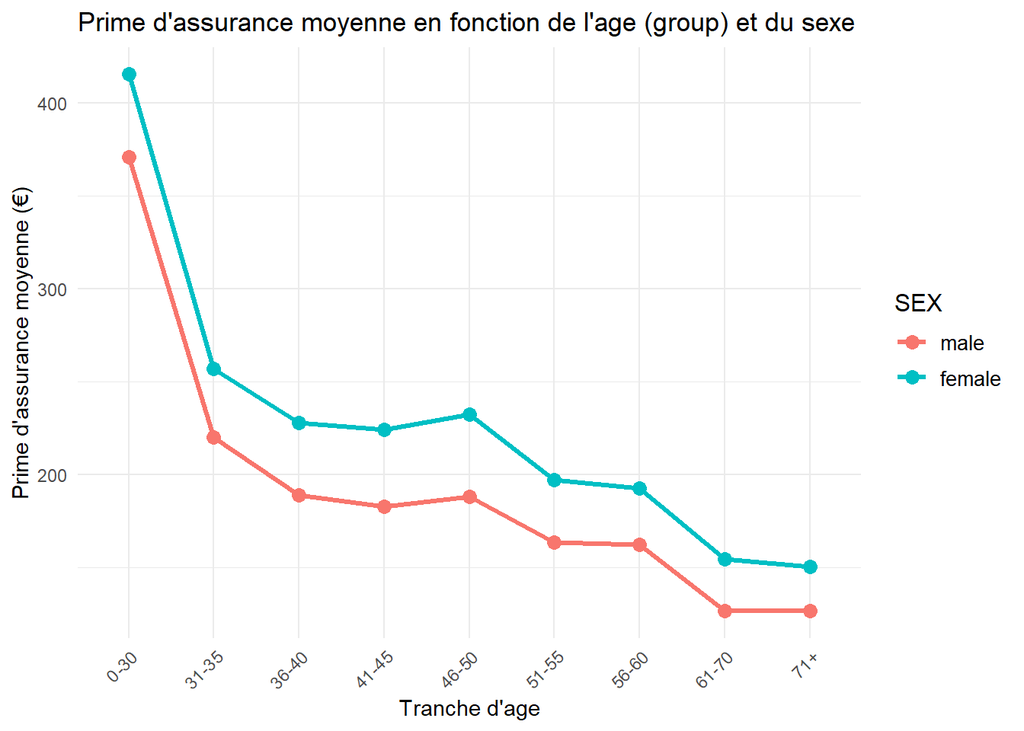

```r
ggplot(summary_data, aes(x = AGEPH_BINNED, y = avg_premium, color = SEX, group = SEX)) +
  geom_line(linewidth = 1.2) +
  geom_point(size = 3) +
  labs(
    title = "Prime d'assurance moyenne en fonction de l'age (group) et du sexe",
    x = "Tranche d'age",
    y = "Prime d'assurance moyenne (€)"
  ) +
  theme_minimal() +
  theme(
    legend.title = element_text(size = 12),
    legend.text = element_text(size = 10),
    axis.text.x = element_text(angle = 45, hjust = 1)
  )
```

### Analyse et interprétation :

### 3.4.1 Tendance générale :

- La **prime d’assurance moyenne** suit une tendance à la baisse avec l’âge, aussi bien pour les hommes que pour les femmes. Cette diminution peut être attribuée à une réduction du risque perçu par les assureurs, les conducteurs plus âgés étant souvent considérés comme plus prudents et moins enclins à des comportements risqués que les jeunes conducteurs.

# 4 **Modélisation GAM**

## 4.1 **Modèle de fréquence avec lissage**

### 4.1.1 **Test de linéarité des variables continues**

Dans cette section, un test de linéarité est effectué sur les variables POWER, BM, LONG et LAG

**Variables LONG et LAT**

```r
linear_model <- gam(NCLAIMS ~ LONG+LAT, data = data)
smooth_model <- gam(NCLAIMS ~ s(LONG, LAT), data = data)
AIC(linear_model, smooth_model)
```

```
##                    df      AIC
## linear_model  4.00000 136523.6
## smooth_model 28.00265 136235.4
```

Dans ce cas, l’AIC du GAM lissé est plus faible, ce qui montre que l’ajout d’une fonction de lissage améliore la performance du modèle. Par conséquent, la linéarité n’est pas confirmée par nos données pour les variables LONG et LAT

**Variable BM**

```r
linear_model <- gam(NCLAIMS ~ BM, data = data)
smooth_model <- gam(NCLAIMS ~ s(BM), data = data)
AIC(linear_model, smooth_model)
```

```
##                    df      AIC
## linear_model 3.000000 134783.2
## smooth_model 7.547828 134765.1
```

L’AIC du GAM lissé etant plus bas alors la linéarité n’est donc pas soutenue par nos données pour la variable Bonus-Malus.

**Variable AGEPH**

```r
linear_model <- gam(NCLAIMS ~ AGEPH, data = data)
smooth_model <- gam(NCLAIMS ~ s(AGEPH), data = data)
AIC(linear_model, smooth_model)
```

```
##                    df      AIC
## linear_model 3.000000 135757.6
## smooth_model 8.334604 135450.3
```

Ici, l’AIC du GAM lissé est plus bas, linéarité n’est donc pas soutenue par nos données pour la variable AGEPH.

**POWER**

```r
linear_model <- gam(NCLAIMS ~ POWER, data = data)
smooth_model <- gam(NCLAIMS ~ s(POWER), data = data)
AIC(linear_model, smooth_model)
```

```
##                    df      AIC
## linear_model 3.000000 136519.0
## smooth_model 8.220773 136479.4
```

En utilisant le meme raisonnement, le modele GAM lissé est plus adéquat sur la variable **POWER**.

### 4.1.2 **Modèle GAM utilisant les variables LONG, LAT**

**Train test Split**

```r
in_training = createDataPartition(data$NCLAIMS, times = 1, p = 0.8, list = FALSE)
training_set = data[in_training, ]
testing_set = data[-in_training_severity, ]
```

#### 4.1.2.1 **Modélisation**

**NB** : Nous ne prendrons pas en compte la variable *regions* car celle-ci est dérivée des variables *LONG* et *LAT*, ce qui pourrait entraîner un risque de corrélation.

```r
model1 <- gam(NCLAIMS ~ offset(log(EXP)) +
                   s(LONG, LAT),
                 family = poisson(link = "log"),
                 data = training_set, method="REML")
```

```r
# Résumé des splines

summary(model1)$s.table
```

```
##                  edf   Ref.df   Chi.sq p-value
## s(LONG,LAT) 24.64871 27.70694 357.9238       0
```

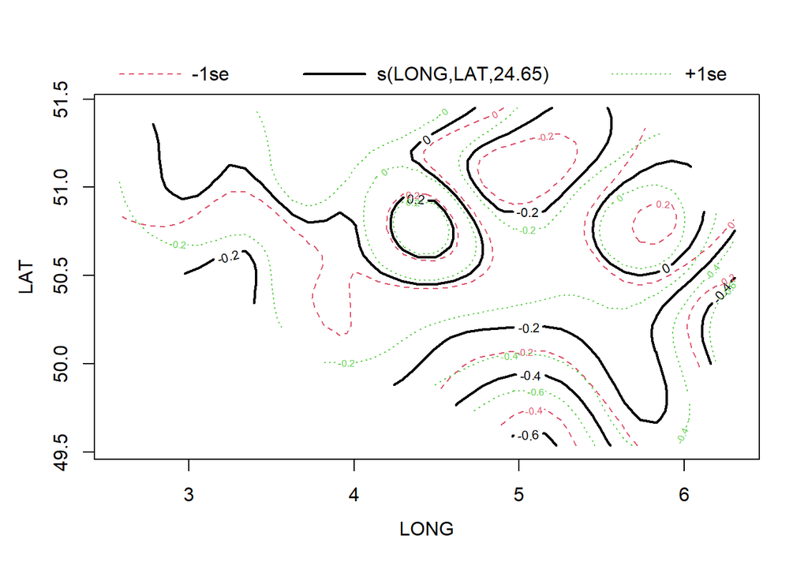

```r
#par(mfrow = c(3, 3))
plot(model1, all.terms = TRUE)
```

### 4.1.3 **Modèle GAM utilisant les variables LONG, LAT et les variables categorielles**

```r
model2 <- gam(NCLAIMS ~ offset(log(EXP)) +
                   s(LONG, LAT)+COVERAGE + FUEL + USE + FLEET + SEX,
                 family = poisson(link = "log"),
                 data = training_set, method="REML")
```

```r
summary(model2)$p.table
```

```
##                Estimate Std. Error      z value     Pr(>|z|)
## (Intercept) -2.00728393 0.01294656 -155.0438276 0.000000e+00
## COVERAGEPO  -0.18031385 0.01906415   -9.4582705 3.130785e-21
## COVERAGEFO  -0.14764946 0.02455908   -6.0120116 1.832352e-09
## FUELdiesel   0.23259928 0.01685422   13.8006515 2.525596e-43
## USEwork     -0.01064084 0.03722336   -0.2858645 7.749819e-01
## FLEETY      -0.25206826 0.04942517   -5.0999976 3.396578e-07
## SEXfemale    0.08950069 0.01778104    5.0334906 4.816285e-07
```

```r
summary(model2)$s.table
```

```
##                  edf  Ref.df Chi.sq p-value
## s(LONG,LAT) 25.30267 28.0353 442.98       0
```

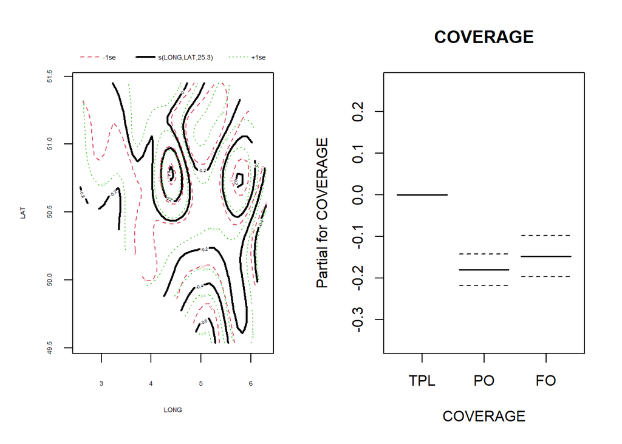

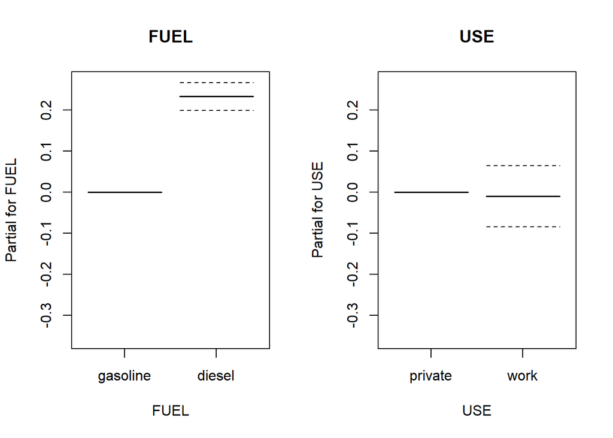

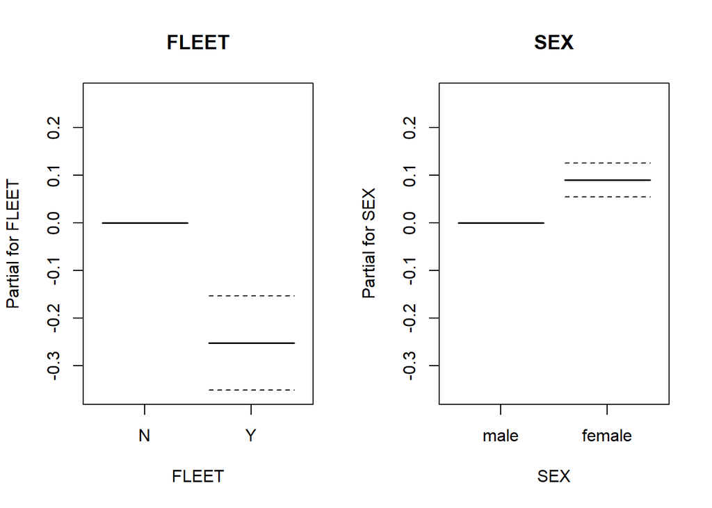

```r
par(mfrow = c(1, 2))
plot(model2, all.terms = TRUE)
```

**Interpretation**

```r
summary(model2)
```

```
##
## Family: poisson
## Link function: log
##
## Formula:
## NCLAIMS ~ offset(log(EXP)) + s(LONG, LAT) + COVERAGE + FUEL +
##     USE + FLEET + SEX
##
## Parametric coefficients:
##             Estimate Std. Error  z value Pr(>|z|)
## (Intercept) -2.00728    0.01295 -155.044  < 2e-16 ***
## COVERAGEPO  -0.18031    0.01906   -9.458  < 2e-16 ***
## COVERAGEFO  -0.14765    0.02456   -6.012 1.83e-09 ***
## FUELdiesel   0.23260    0.01685   13.801  < 2e-16 ***
## USEwork     -0.01064    0.03722   -0.286    0.775
## FLEETY      -0.25207    0.04943   -5.100 3.40e-07 ***
## SEXfemale    0.08950    0.01778    5.033 4.82e-07 ***
## ---
## Signif. codes:  0 '***' 0.001 '**' 0.01 '*' 0.05 '.' 0.1 ' ' 1
##
## Approximate significance of smooth terms:
##              edf Ref.df Chi.sq p-value
## s(LONG,LAT) 25.3  28.04    443  <2e-16 ***
## ---
## Signif. codes:  0 '***' 0.001 '**' 0.01 '*' 0.05 '.' 0.1 ' ' 1
##
## R-sq.(adj) =  0.00585   Deviance explained = 0.991%
## -REML =  50591  Scale est. = 1         n = 130585
```

### 4.1.4 **Modèle GAM utilisant les variables (LONG, LAT),AGEPH,Power et BM**

```r
model3 <- gam(NCLAIMS ~ offset(log(EXP)) + s(AGEPH)+s(POWER)+s(BM)+
                   s(LONG, LAT),
                 family = poisson(link = "log"),
                 data = training_set, method="REML")
```

```r
summary(model3)
```

```
##
## Family: poisson
## Link function: log
##
## Formula:
## NCLAIMS ~ offset(log(EXP)) + s(AGEPH) + s(POWER) + s(BM) + s(LONG,
##     LAT)
##
## Parametric coefficients:
##              Estimate Std. Error z value Pr(>|z|)
## (Intercept) -2.030699   0.008296  -244.8   <2e-16 ***
## ---
## Signif. codes:  0 '***' 0.001 '**' 0.01 '*' 0.05 '.' 0.1 ' ' 1
##
## Approximate significance of smooth terms:
##                edf Ref.df Chi.sq p-value
## s(AGEPH)     5.838  6.873 252.29  <2e-16 ***
## s(POWER)     6.049  6.969  92.57  <2e-16 ***
## s(BM)        5.242  6.248 859.22  <2e-16 ***
## s(LONG,LAT) 22.796 26.587 243.97  <2e-16 ***
## ---
## Signif. codes:  0 '***' 0.001 '**' 0.01 '*' 0.05 '.' 0.1 ' ' 1
##
## R-sq.(adj) =  0.018   Deviance explained = 3.28%
## -REML =  49782  Scale est. = 1         n = 130585
```

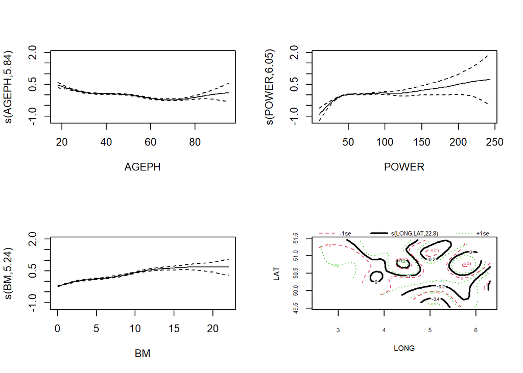

```r
par(mfrow = c(2, 2))
plot(model3, all.terms = TRUE)
```

### 4.1.5 **Modèle GAM en utilisant toutes les variables**

```r
model4 <- gam(NCLAIMS ~ offset(log(EXP)) + s(AGEPH)+s(POWER)+s(BM)+
                   s(LONG, LAT)+COVERAGE + FUEL + USE + FLEET + SEX,
                 family = poisson(link = "log"),
                 data = training_set, method="REML")
```

```r
summary(model4)
```

```
##
## Family: poisson
## Link function: log
##
## Formula:
## NCLAIMS ~ offset(log(EXP)) + s(AGEPH) + s(POWER) + s(BM) + s(LONG,
##     LAT) + COVERAGE + FUEL + USE + FLEET + SEX
##
## Parametric coefficients:
##             Estimate Std. Error  z value Pr(>|z|)
## (Intercept) -2.03747    0.01327 -153.550  < 2e-16 ***
## COVERAGEPO  -0.11926    0.01929   -6.184 6.26e-10 ***
## COVERAGEFO  -0.12168    0.02505   -4.858 1.19e-06 ***
## FUELdiesel   0.18733    0.01780   10.522  < 2e-16 ***
## USEwork     -0.07047    0.03775   -1.867 0.061950 .
## FLEETY      -0.16645    0.04955   -3.359 0.000781 ***
## SEXfemale    0.01626    0.01841    0.883 0.377222
## ---
## Signif. codes:  0 '***' 0.001 '**' 0.01 '*' 0.05 '.' 0.1 ' ' 1
##
## Approximate significance of smooth terms:
##                edf Ref.df Chi.sq p-value
## s(AGEPH)     5.879  6.913 217.18  <2e-16 ***
## s(POWER)     4.729  5.687  99.48  <2e-16 ***
## s(BM)        5.166  6.172 801.29  <2e-16 ***
## s(LONG,LAT) 23.655 27.142 297.87  <2e-16 ***
## ---
## Signif. codes:  0 '***' 0.001 '**' 0.01 '*' 0.05 '.' 0.1 ' ' 1
##
## R-sq.(adj) =  0.0193   Deviance explained = 3.51%
## -REML =  49716  Scale est. = 1         n = 130585
```

Le modèle montre que les variables USE et SEX ne sont pas significatives au seuil de 5 %. Par conséquent, nous allons les retirer, réestimer le modèle, puis le réévaluer.

```r
model5 <- gam(NCLAIMS ~ offset(log(EXP)) + s(AGEPH)+s(POWER)+s(BM)+
                   s(LONG, LAT)+COVERAGE + FUEL + FLEET,
                 family = poisson(link = "log"),
                 data = training_set, method="REML")
```

```r
summary(model5)
```

```
##
## Family: poisson
## Link function: log
##
## Formula:
## NCLAIMS ~ offset(log(EXP)) + s(AGEPH) + s(POWER) + s(BM) + s(LONG,
##     LAT) + COVERAGE + FUEL + FLEET
##
## Parametric coefficients:
##             Estimate Std. Error  z value Pr(>|z|)
## (Intercept) -2.03422    0.01213 -167.769  < 2e-16 ***
## COVERAGEPO  -0.11979    0.01927   -6.215 5.13e-10 ***
## COVERAGEFO  -0.12512    0.02493   -5.019 5.20e-07 ***
## FUELdiesel   0.18254    0.01761   10.367  < 2e-16 ***
## FLEETY      -0.17186    0.04941   -3.478 0.000505 ***
## ---
## Signif. codes:  0 '***' 0.001 '**' 0.01 '*' 0.05 '.' 0.1 ' ' 1
##
## Approximate significance of smooth terms:
##                edf Ref.df Chi.sq p-value
## s(AGEPH)     5.879  6.913 224.75  <2e-16 ***
## s(POWER)     4.784  5.745  97.54  <2e-16 ***
## s(BM)        5.183  6.189 803.59  <2e-16 ***
## s(LONG,LAT) 23.662 27.145 298.98  <2e-16 ***
## ---
## Signif. codes:  0 '***' 0.001 '**' 0.01 '*' 0.05 '.' 0.1 ' ' 1
##
## R-sq.(adj) =  0.0193   Deviance explained =  3.5%
## -REML =  49713  Scale est. = 1         n = 130585
```

### 4.1.6 **Comparaison des différents modèles GAM en utilisant le BIC et AIC**

```r
BIC(model1,model2,model3,model4,model5)
```

```
##              df       BIC
## model1 26.14057 101668.27
## model2 32.70393 101413.05
## model3 43.05389  99892.67
## model4 49.76345  99808.69
## model5 47.78941  99789.39
```

```r
AIC(model1,model2,model3,model4,model5)
```

```
##              df       AIC
## model1 26.14057 101412.62
## model2 32.70393 101093.21
## model3 43.05389  99471.61
## model4 49.76345  99322.01
## model5 47.78941  99322.02
```

**Sur la base du BIC, le modèle 5, qui inclut les variables AGEPH, POWER, BM, LONG, LAT, COVERAGE, FUEL et FLEET, est meilleur que les modèles.**

## 4.2 **Modele GAM vs GLM**

```r
BIC(model5,step_result)
```

```
##                   df       BIC
## model5      47.78941  99789.39
## step_result 22.00000 100206.27
```

```r
AIC(model5,step_result)
```

```
##                   df      AIC
## model5      47.78941 99322.02
## step_result 22.00000 99991.12
```

**Sur la base de l’AIC et du BIC, le modèle *GAM* optimisé est meilleur que modèle *GLM* optimisé**

# 5 **Annexes**

## 5.1 **Analyse de la correlations des variables explications à la variable reponse (NCLAIMS)**

```r
cat_vars <- c("COVERAGE", "FUEL", "SEX", "USE", "FLEET", "AGEPH_BINNED", "POWER_BINNED", "BM_BINNED", "REGIONS","AGEC_BINNED")

compute_chi_square <- function(var_name) {

  contingency_table <- table(data[[var_name]], data$NCLAIMS)

  test_result <- chisq.test(contingency_table)

  if (any(test_result$expected < 5)) {
    warning(paste("Attention : l'approximation du Khi-2 peut être incorrecte pour la variable", var_name))
  }

  return(test_result$p.value)
}

chi_square_results <- sapply(cat_vars, compute_chi_square)
```

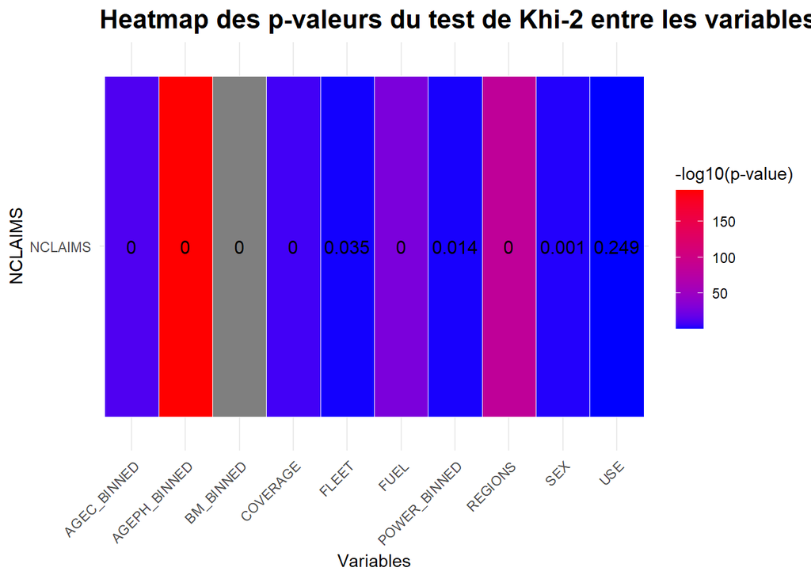

```r
results_df <- data.frame(
  Variable = cat_vars,
  P_Value = chi_square_results
)


results_df <- results_df %>%
  mutate(Significance = case_when(
    P_Value < 0.001 ~ "***",
    P_Value < 0.01 ~ "**",
    P_Value < 0.05 ~ "*",
    TRUE ~ "ns" # Non significatif
  ))

heatmap_data <- results_df %>%
  mutate(Log_P_Value = -log10(P_Value))

ggplot(heatmap_data, aes(x = Variable, y = "NCLAIMS", fill = Log_P_Value)) +
  geom_tile(color = "white") +
  geom_text(aes(label = round(P_Value, 3)), color = "black", size = 4) +
  scale_fill_gradient(low = "blue", high = "red", name = "-log10(p-value)") +
  labs(
    title = "Heatmap des p-valeurs du test de Khi-2 entre les variables et NCLAIMS",
    x = "Variables",
    y = "NCLAIMS"
  ) +
  theme_minimal() +
  theme(
    axis.text.x = element_text(angle = 45, hjust = 1),
    plot.title = element_text(size = 16, face = "bold")
  )
```

```r
print(results_df)
```

```
##                  Variable       P_Value Significance
## COVERAGE         COVERAGE  1.179610e-08          ***
## FUEL                 FUEL  2.110431e-29          ***
## SEX                   SEX  1.344805e-03           **
## USE                   USE  2.489660e-01           ns
## FLEET               FLEET  3.494590e-02            *
## AGEPH_BINNED AGEPH_BINNED 3.203905e-193          ***
## POWER_BINNED POWER_BINNED  1.396842e-02            *
## BM_BINNED       BM_BINNED  0.000000e+00          ***
## REGIONS           REGIONS  1.462236e-84          ***
## AGEC_BINNED   AGEC_BINNED  5.306715e-12          ***
```

1. **AGEPH_BINNED (Âge de l’assuré)** :
   - **P-valeur proche de 0**.
   - Relation hautement significative entre l’âge des assurés et le nombre de sinistres.
   - L’âge est un facteur important pour expliquer la fréquence des sinistres.
2. **BM_BINNED (Bonus-Malus)** :
   - **P-valeur proche de 0**.
   - Relation hautement significative, ce qui est attendu, car le Bonus-Malus est directement lié au comportement de conduite.
3. **COVERAGE (Type de couverture)** :
   - **P-valeur proche de 0**.
   - Relation significative entre le type de couverture et le nombre de sinistres.
4. **FLEET (Appartenance à une flotte)** :
   - **P-valeur de 0,035** .
   - Relation significative, bien que moins forte par rapport à AGEPH_BINNED ou BM_BINNED.
   - Cela peut indiquer que les véhicules appartenant à des flottes ont un comportement sinistre différent.
5. **POWER_BINNED (Puissance du véhicule)** :
   - **P-valeur de 0,014**.
   - Relation significative, mais moins forte que les autres variables clés.
   - La puissance du véhicule joue un rôle dans la fréquence des sinistres, mais son impact est modéré.
6. **SEX (Sexe de l’assuré)** :
   - **P-valeur de 0,001**.
   - Relation significative, bien que moins forte par rapport à d’autres variables comme AGEPH_BINNED ou BM_BINNED.
7. **USE (Usage du véhicule)** :
   - **P-valeur de 0,249**.
   - Pas de relation statistiquement significative entre l’usage du véhicule (privé ou professionnel) et le nombre de sinistres.

## 5.2 **Effet des variables explicatives sur la fréquence des sinistres (modèle step_result) du modele GLM**

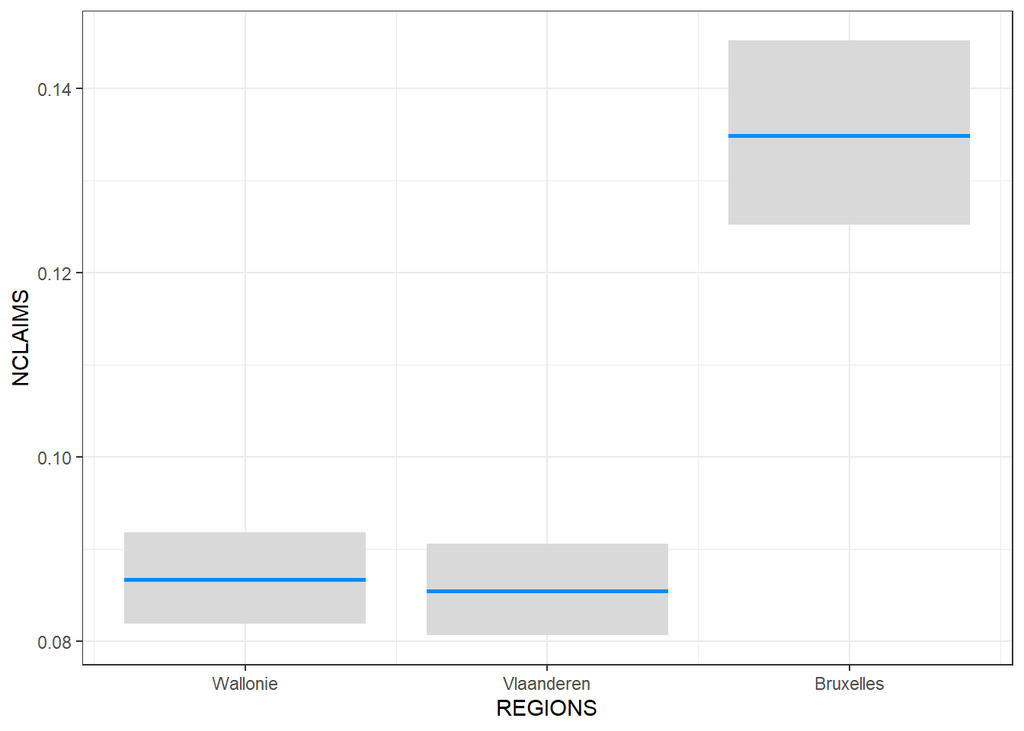

```r
visreg(step_result, "REGIONS", type="conditional", scale="response", gg=TRUE, rug=FALSE, partial=FALSE) + theme_bw()
```

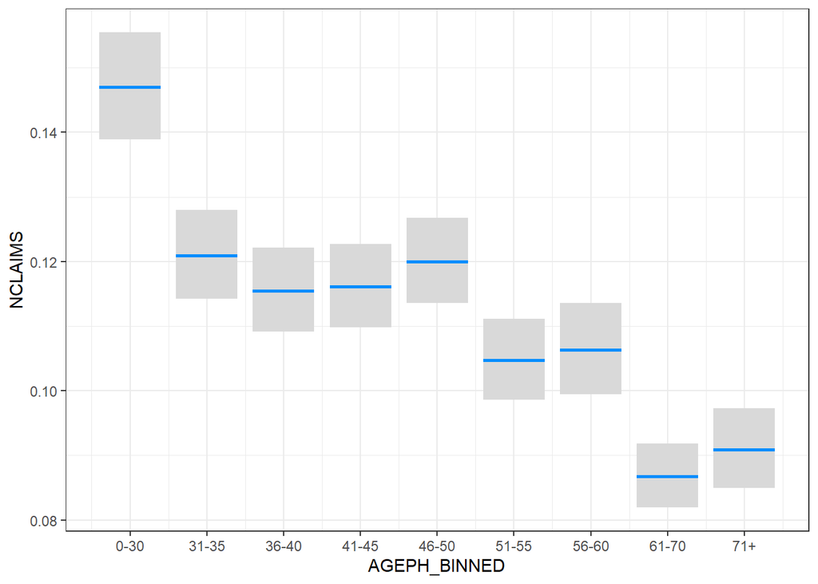

```r
visreg(step_result, "AGEPH_BINNED", type="conditional", scale="response", gg=TRUE, rug=FALSE, partial=FALSE) + theme_bw()
```

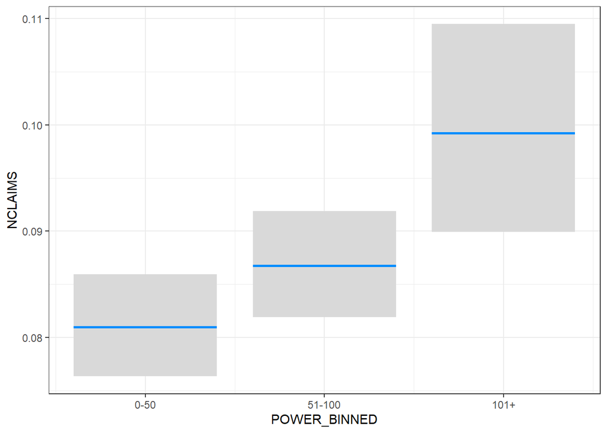

```r
visreg(step_result, "POWER_BINNED", type="conditional", scale="response", gg=TRUE, rug=FALSE, partial=FALSE) + theme_bw()
```

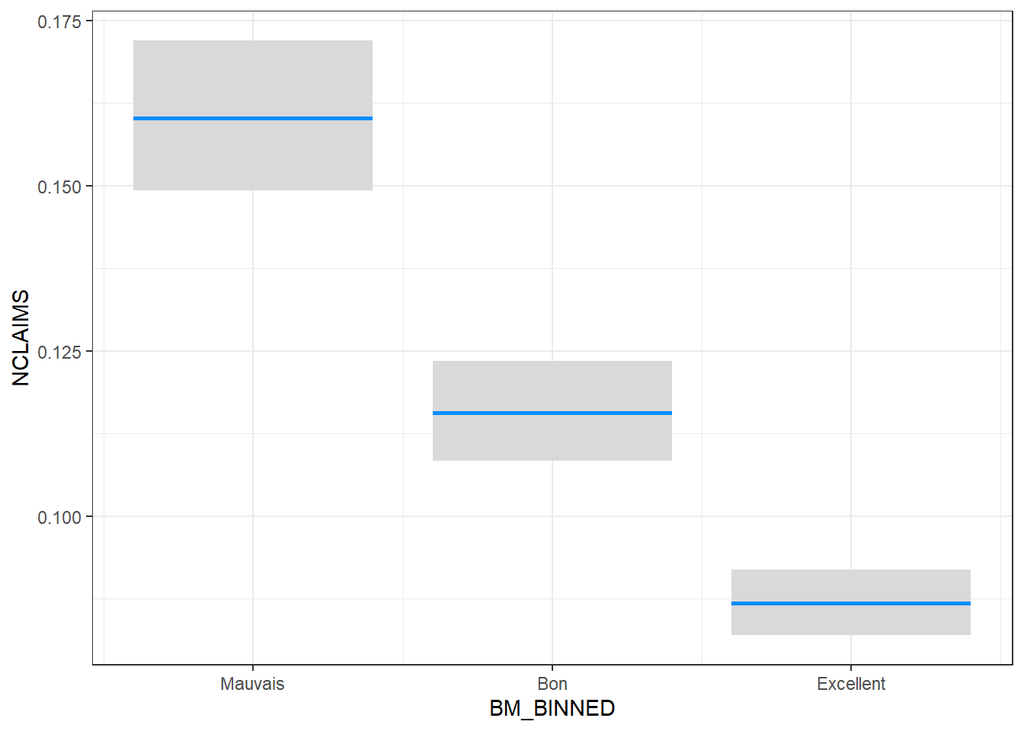

```r
visreg(step_result, "BM_BINNED", type="conditional", scale="response", gg=TRUE, rug=FALSE, partial=FALSE) + theme_bw()
```

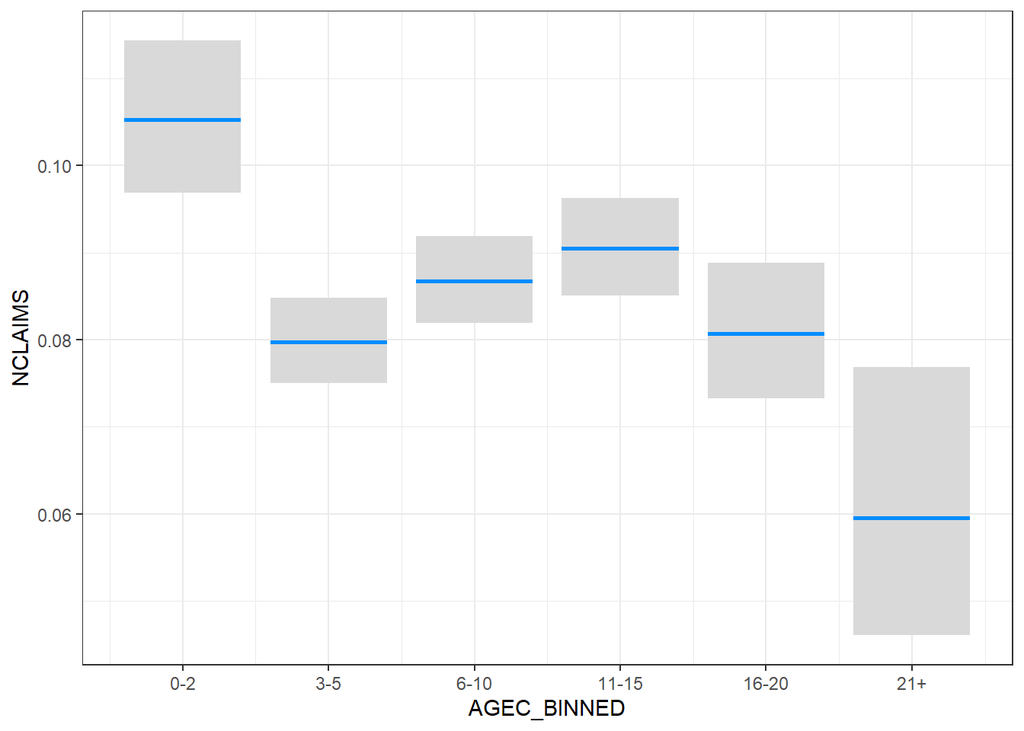

```r
visreg(step_result, "AGEC_BINNED", type="conditional", scale="response", gg=TRUE, rug=FALSE, partial=FALSE) + theme_bw()
```

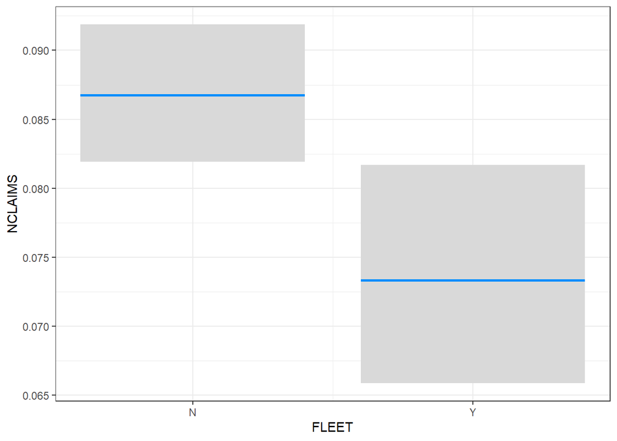

```r
visreg(step_result, "FLEET", type="conditional", scale="response", gg=TRUE, rug=FALSE, partial=FALSE) + theme_bw()
```

## 5.3 **Ressources**

Pour ce projet, nous avons utilisé les ressources suivantes :

- **https://rpubs.com/afm/904650**
- **https://r.qcbs.ca/workshop08/book-fr/gam-avec-plusieurs-termes-non-lin%C3%A9aires.html**
- Les ressources du cours, incluant les cours et les codes fournis.